# Share of households with broadband access in the home

Author

Manu Alcalá Kovalski

Published

October 4, 2024

```r
options(scipen = 999)

library(tidyverse)
library(urbnthemes)
library(tidycensus)
library(censusapi)
library(glue)
library(janitor)
library(tidylog)
library(skimr)

set_urbn_defaults(style = "print")
```

This metric shows the ratio of households with the presence of a computer and a type of broadband internet subscription in their household (we calculate the overall ratio, as well as by racial subgroup - measured according to the race of each head of the household).

## Process

1. Housekeeping
2. Pull demographics for Census Places and Census Counties
3. Clean and reshape to move data into the vars we want
4. Calculate the digital access metric
5. Create a data quality flag
6. Cleaning and export

## Housekeeping

```r
# Explore where to pull data from
acs5_vars <- load_variables(2021, "acs5", cache = TRUE)
acs1_vars <- load_variables(2021, "acs1", cache = TRUE)
acs1_subject_vars <- load_variables(2021, "acs1/subject", cache = TRUE)
```

## Pull demographics for Census Places and Census Counties

```r
pull_census_data <- function(vars, geography, survey, years) {
  census_data <- map_dfr(years, ~ get_acs(
    geography = {{ geography }},
    variables = vars,
    survey = survey,
    year = .x,
    moe_level = 95
  ) %>%
    mutate(year = .x) %>%
    pivot_wider(names_from = variable, values_from = c(estimate, moe))) %>%
    rename_with(
      ~ str_remove(.x, "estimate_"),
      starts_with("estimate_")
    ) |>
    clean_names()


  if (geography == "county") {
    census_data <- census_data %>%
      filter(!str_detect(geoid, "^72"))
  }


  return(census_data)
}
```

### Communities overall

- Unit of analysis: Households,
- Survey: ACS 5
- Census table: B28003
- Years: 2018, 2021

We are using the 5-yr ACS for the communities overall (and subgroups), from 2018 to 2021. This will be based on table B28003.

```r
# "Population" variables refer to households/people in households in a
# given category.

# "Digital" variables (those with a "digital" prefix) refer to households/people in households in a given category that have a computer with a broadband internet subscription.

years <- c(2018, 2021)

overall_vars <-
  c( # Population variables
    "total_households" = "B28003_001",
    # Digital variables
    "total_households_digital" = "B28003_004"
  )

# Apply our function to multiple datasets using map2 and assigns the results
# back to the specified object names in the global environment, reducing repetitive code such as:
# county_overall <- pull_census_data(geography = "county",
#                                    vars = overall_vars,
#                                    years = acs1_years,
#                                    survey = "acs1")
# place_overall <- pull_census_data(geography = "place",
#                                    vars = overall_vars,
#                                    years = acs1_years,
#                                    survey = "acs1")
map(
  .x = c("county", "place"),
  .f = ~ assign(
    x = paste0(.x, "_overall"),
    value = pull_census_data(
      geography = .x,
      vars = overall_vars,
      years = years,
      survey = "acs5"
    ),
    envir = .GlobalEnv
  )
)
```

```
[[1]]
# A tibble: 6,285 x 7
   geoid name                      year total_households total_households_digi~1
   <chr> <chr>                    <dbl>            <dbl>                   <dbl>
 1 01001 Autauga County, Alabama   2018            21115                   16549
 2 01003 Baldwin County, Alabama   2018            78622                   61121
 3 01005 Barbour County, Alabama   2018             9186                    5490
 4 01007 Bibb County, Alabama      2018             6840                    4455
 5 01009 Blount County, Alabama    2018            20600                   13951
 6 01011 Bullock County, Alabama   2018             3609                    2097
 7 01013 Butler County, Alabama    2018             6708                    4051
 8 01015 Calhoun County, Alabama   2018            45033                   32484
 9 01017 Chambers County, Alabama  2018            13516                    8825
10 01019 Cherokee County, Alabama  2018            10606                    7216
# i 6,275 more rows
# i abbreviated name: 1: total_households_digital
# i 2 more variables: moe_total_households <dbl>,
#   moe_total_households_digital <dbl>

[[2]]
# A tibble: 61,481 x 7
   geoid   name                     year total_households total_households_dig~1
   <chr>   <chr>                   <dbl>            <dbl>                  <dbl>
 1 0100100 Abanda CDP, Alabama      2018               88                     26
 2 0100124 Abbeville city, Alabama  2018              993                    615
 3 0100460 Adamsville city, Alaba~  2018             1472                   1068
 4 0100484 Addison town, Alabama    2018              308                    193
 5 0100676 Akron town, Alabama      2018              117                     51
 6 0100820 Alabaster city, Alabama  2018            11227                   9840
 7 0100988 Albertville city, Alab~  2018             7343                   5479
 8 0101132 Alexander City city, A~  2018             6081                   4249
 9 0101180 Alexandria CDP, Alabama  2018             1475                   1298
10 0101228 Aliceville city, Alaba~  2018              851                    466
# i 61,471 more rows
# i abbreviated name: 1: total_households_digital
# i 2 more variables: moe_total_households <dbl>,
#   moe_total_households_digital <dbl>
```

```r
# 4,969 rows
skim(county_overall)
```

Data summary

| Name | county_overall |
| --- | --- |
| Number of rows | 6285 |
| Number of columns | 7 |
| _______________________ |  |
| Column type frequency: |  |
| character | 2 |
| numeric | 5 |
| ________________________ |  |
| Group variables | None |

**Variable type: character**

| skim_variable | n_missing | complete_rate | min | max | empty | n_unique | whitespace |
| --- | --- | --- | --- | --- | --- | --- | --- |
| geoid | 0 | 1 | 5 | 5 | 0 | 3144 | 0 |
| name | 0 | 1 | 16 | 42 | 0 | 3144 | 0 |

**Variable type: numeric**

| skim_variable | n_missing | complete_rate | mean | sd | p0 | p25 | p50 | p75 | p100 | hist |
| --- | --- | --- | --- | --- | --- | --- | --- | --- | --- | --- |
| year | 0 | 1 | 2019.50 | 1.50 | 2018.00 | 2018.00 | 2021.00 | 2021.00 | 2021.00 | ▇▁▁▁▇ |
| total_households | 0 | 1 | 38781.40 | 117935.65 | 31.00 | 4165.00 | 9841.00 | 26056.00 | 3342811.00 | ▇▁▁▁▁ |
| total_households_digital | 0 | 1 | 32211.24 | 100728.17 | 20.00 | 2944.00 | 7302.00 | 20487.00 | 2949344.00 | ▇▁▁▁▁ |
| moe_total_households | 0 | 1 | 468.29 | 460.65 | 10.72 | 210.89 | 339.57 | 556.43 | 6592.51 | ▇▁▁▁▁ |
| moe_total_households_digital | 0 | 1 | 582.07 | 624.28 | 9.53 | 239.49 | 409.87 | 685.11 | 9975.15 | ▇▁▁▁▁ |

```r
# 3,763 rows
skim(place_overall)
```

Data summary

| Name | place_overall |
| --- | --- |
| Number of rows | 61481 |
| Number of columns | 7 |
| _______________________ |  |
| Column type frequency: |  |
| character | 2 |
| numeric | 5 |
| ________________________ |  |
| Group variables | None |

**Variable type: character**

| skim_variable | n_missing | complete_rate | min | max | empty | n_unique | whitespace |
| --- | --- | --- | --- | --- | --- | --- | --- |
| geoid | 0 | 1 | 7 | 7 | 0 | 32005 | 0 |
| name | 0 | 1 | 12 | 66 | 0 | 32073 | 0 |

**Variable type: numeric**

| skim_variable | n_missing | complete_rate | mean | sd | p0 | p25 | p50 | p75 | p100 | hist |
| --- | --- | --- | --- | --- | --- | --- | --- | --- | --- | --- |
| year | 0 | 1 | 2019.56 | 1.50 | 2018.00 | 2018.00 | 2021.00 | 2021.00 | 2021.00 | ▇▁▁▁▇ |
| total_households | 0 | 1 | 3008.40 | 25365.34 | 0.00 | 120.00 | 399.00 | 1498.00 | 3250657.00 | ▇▁▁▁▁ |
| total_households_digital | 0 | 1 | 2502.55 | 20918.17 | 0.00 | 86.00 | 297.00 | 1210.00 | 2765573.00 | ▇▁▁▁▁ |
| moe_total_households | 0 | 1 | 160.58 | 206.96 | 1.19 | 45.28 | 96.51 | 198.98 | 8359.49 | ▇▁▁▁▁ |
| moe_total_households_digital | 0 | 1 | 158.12 | 228.76 | 1.19 | 38.13 | 86.98 | 195.40 | 11961.36 | ▇▁▁▁▁ |

### Race/ethnicity subgroup

- Unit of analysis: Population in households,
- Survey: ACS 5
- Census table(s): B28009, S2802 (subject table)
- Years: 2018, 2021

```r
acs5_years <- c(2018, 2021)

raceeth_vars <-
  c( # Population variables
    "total_people_in_households" = "S2802_C01_001",
    "white" = "B28009A_001",
    "black" = "B28009B_001",
    "aian" = "B28009C_001",
    "asian" = "B28009D_001",
    "nhpi" = "B28009E_001",
    "other" = "B28009F_001",
    "two_or_more" = "B28009G_001",
    "hispanic" = "B28009I_001",
    # Digital variables
    "total_people_in_households_digital" = "S2802_C02_001",
    "white_digital" = "S2802_C02_005",
    "black_digital" = "S2802_C02_006",
    "aian_digital" = "S2802_C02_007",
    "asian_digital" = "S2802_C02_008",
    "nhpi_digital" = "S2802_C02_009",
    "other_digital" = "S2802_C02_010",
    "two_or_more_digital" = "S2802_C02_011",
    "hispanic_digital" = "S2802_C02_012"
  )

map(
  .x = c("county", "place"),
  .f = ~ assign(
    x = paste0(.x, "_raceeth"),
    value = pull_census_data(
      geography = .x,
      vars = raceeth_vars,
      years = acs5_years,
      survey = "acs5"
    ),
    envir = .GlobalEnv
  )
)
```

```
[[1]]
# A tibble: 6,285 x 39
   geoid name     year  white black  aian asian  nhpi other two_or_more hispanic
   <chr> <chr>   <dbl>  <dbl> <dbl> <dbl> <dbl> <dbl> <dbl>       <dbl>    <dbl>
 1 01001 Autaug~  2018  42052 10445   145   568    32   407        1005     1526
 2 01003 Baldwi~  2018 177477 18960  1424  1680     9  2028        3515     9305
 3 01005 Barbou~  2018  11153 10564     9    96     1   752         307      995
 4 01007 Bibb C~  2018  16408  3849     0    37     0     0         142      464
 5 01009 Blount~  2018  54694   682   141   198    18   436         933     5260
 6 01011 Bulloc~  2018   2122  7619   122    56     0     3           0       50
 7 01013 Butler~  2018  10162  8985     2   231     0     0         323       67
 8 01015 Calhou~  2018  83644 22573   352  1059     9  1697        2652     4129
 9 01017 Chambe~  2018  19180 13126    81   405     0   175         347      764
10 01019 Cherok~  2018  23775  1215   236    55     0    90         208      398
# i 6,275 more rows
# i 28 more variables: total_people_in_households <dbl>,
#   total_people_in_households_digital <dbl>, white_digital <dbl>,
#   black_digital <dbl>, aian_digital <dbl>, asian_digital <dbl>,
#   nhpi_digital <dbl>, other_digital <dbl>, two_or_more_digital <dbl>,
#   hispanic_digital <dbl>, moe_white <dbl>, moe_black <dbl>, moe_aian <dbl>,
#   moe_asian <dbl>, moe_nhpi <dbl>, moe_other <dbl>, ...

[[2]]
# A tibble: 61,481 x 39
   geoid   name    year white black  aian asian  nhpi other two_or_more hispanic
   <chr>   <chr>  <dbl> <dbl> <dbl> <dbl> <dbl> <dbl> <dbl>       <dbl>    <dbl>
 1 0100100 Aband~  2018   174    44     0     0     0     0           0        0
 2 0100124 Abbev~  2018  1423   973     0     0     0     9           0      109
 3 0100460 Adams~  2018  1898  2312    48     0    11     8          69        8
 4 0100484 Addis~  2018   627     0     3     0     0     0          11        0
 5 0100676 Akron~  2018    75   215     0     0     0     0           0        0
 6 0100820 Alaba~  2018 23946  4689   113   417     6  2503         909     3110
 7 0100988 Alber~  2018 19316   698    54   124     0   634         318     6488
 8 0101132 Alexa~  2018  8716  4723    49   135     0   540         121      795
 9 0101180 Alexa~  2018  3380   602    18     0     0     0           0       65
10 0101228 Alice~  2018   408  1882     0     0     0     0           5        0
# i 61,471 more rows
# i 28 more variables: total_people_in_households <dbl>,
#   total_people_in_households_digital <dbl>, white_digital <dbl>,
#   black_digital <dbl>, aian_digital <dbl>, asian_digital <dbl>,
#   nhpi_digital <dbl>, other_digital <dbl>, two_or_more_digital <dbl>,
#   hispanic_digital <dbl>, moe_white <dbl>, moe_black <dbl>, moe_aian <dbl>,
#   moe_asian <dbl>, moe_nhpi <dbl>, moe_other <dbl>, ...
```

```r
skim(county_raceeth)
```

Data summary

| Name | county_raceeth |
| --- | --- |
| Number of rows | 6285 |
| Number of columns | 39 |
| _______________________ |  |
| Column type frequency: |  |
| character | 2 |
| numeric | 37 |
| ________________________ |  |
| Group variables | None |

**Variable type: character**

| skim_variable | n_missing | complete_rate | min | max | empty | n_unique | whitespace |
| --- | --- | --- | --- | --- | --- | --- | --- |
| geoid | 0 | 1 | 5 | 5 | 0 | 3144 | 0 |
| name | 0 | 1 | 16 | 42 | 0 | 3144 | 0 |

**Variable type: numeric**

| skim_variable | n_missing | complete_rate | mean | sd | p0 | p25 | p50 | p75 | p100 | hist |
| --- | --- | --- | --- | --- | --- | --- | --- | --- | --- | --- |
| year | 0 | 1 | 2019.50 | 1.50 | 2018.00 | 2018.00 | 2021.00 | 2021.00 | 2021.00 | ▇▁▁▁▇ |
| white | 0 | 1 | 71517.17 | 190749.27 | 10.00 | 8444.00 | 20888.00 | 55847.00 | 5094576.00 | ▇▁▁▁▁ |
| black | 0 | 1 | 12536.07 | 54470.27 | 0.00 | 70.00 | 552.00 | 4927.00 | 1201026.00 | ▇▁▁▁▁ |
| aian | 0 | 1 | 834.00 | 3622.49 | 0.00 | 23.00 | 97.00 | 398.00 | 97092.00 | ▇▁▁▁▁ |
| asian | 0 | 1 | 5673.39 | 41249.45 | 0.00 | 31.00 | 137.00 | 711.00 | 1453102.00 | ▇▁▁▁▁ |
| nhpi | 0 | 1 | 184.40 | 2026.22 | 0.00 | 0.00 | 3.00 | 37.00 | 99543.00 | ▇▁▁▁▁ |
| other | 0 | 1 | 5348.06 | 46546.20 | 0.00 | 49.00 | 247.00 | 1159.00 | 2180772.00 | ▇▁▁▁▁ |
| two_or_more | 0 | 1 | 5213.15 | 25147.15 | 0.00 | 223.00 | 654.00 | 2313.00 | 1023770.00 | ▇▁▁▁▁ |
| hispanic | 0 | 1 | 18489.45 | 125360.36 | 0.00 | 317.00 | 1009.00 | 4966.00 | 4845150.00 | ▇▁▁▁▁ |
| total_people_in_households | 0 | 1 | 101306.24 | 326295.98 | 38.00 | 10515.00 | 24783.00 | 65245.00 | 9920572.00 | ▇▁▁▁▁ |
| total_people_in_households_digital | 0 | 1 | 88231.16 | 288857.62 | 30.00 | 8028.00 | 19843.00 | 55332.00 | 8967688.00 | ▇▁▁▁▁ |
| white_digital | 0 | 1 | 62816.75 | 170380.71 | 8.00 | 6634.00 | 17007.00 | 47071.00 | 4335406.00 | ▇▁▁▁▁ |
| black_digital | 0 | 1 | 10059.43 | 44338.08 | 0.00 | 52.00 | 426.00 | 3488.00 | 1000639.00 | ▇▁▁▁▁ |
| aian_digital | 0 | 1 | 622.66 | 2611.70 | 0.00 | 16.00 | 74.00 | 320.00 | 89329.00 | ▇▁▁▁▁ |
| asian_digital | 0 | 1 | 5321.87 | 38725.53 | 0.00 | 25.00 | 121.00 | 645.00 | 1370496.00 | ▇▁▁▁▁ |
| nhpi_digital | 0 | 1 | 155.50 | 1719.79 | 0.00 | 0.00 | 0.00 | 30.00 | 87385.00 | ▇▁▁▁▁ |
| other_digital | 0 | 1 | 4483.28 | 39388.04 | 0.00 | 35.00 | 180.00 | 921.00 | 1937114.00 | ▇▁▁▁▁ |
| two_or_more_digital | 0 | 1 | 4771.68 | 23408.99 | 0.00 | 180.00 | 551.00 | 2044.00 | 966811.00 | ▇▁▁▁▁ |
| hispanic_digital | 0 | 1 | 15555.78 | 106053.84 | 0.00 | 245.00 | 810.00 | 4011.00 | 4317483.00 | ▇▁▁▁▁ |
| moe_white | 0 | 1 | 648.05 | 1099.11 | 3.57 | 166.81 | 314.55 | 660.09 | 19162.72 | ▇▁▁▁▁ |
| moe_black | 0 | 1 | 330.30 | 514.43 | 2.38 | 54.81 | 158.47 | 365.79 | 5946.72 | ▇▁▁▁▁ |
| moe_aian | 0 | 1 | 155.06 | 247.58 | 1.19 | 28.60 | 73.87 | 173.96 | 5128.17 | ▇▁▁▁▁ |
| moe_asian | 0 | 1 | 179.52 | 348.48 | 1.19 | 27.40 | 70.30 | 175.15 | 5909.79 | ▇▁▁▁▁ |
| moe_nhpi | 0 | 1 | 55.04 | 103.47 | 1.19 | 17.87 | 26.21 | 46.47 | 2348.43 | ▇▁▁▁▁ |
| moe_other | 0 | 1 | 485.66 | 1060.91 | 2.38 | 54.81 | 170.38 | 465.87 | 22133.11 | ▇▁▁▁▁ |
| moe_two_or_more | 0 | 1 | 525.06 | 937.40 | 3.57 | 107.23 | 229.96 | 537.36 | 17015.66 | ▇▁▁▁▁ |
| moe_hispanic | 0 | 1 | 97.03 | 153.56 | 1.19 | 19.06 | 48.85 | 115.57 | 2248.34 | ▇▁▁▁▁ |
| moe_total_people_in_households | 2 | 1 | 332.80 | 399.81 | 1.19 | 109.62 | 203.74 | 397.36 | 5034.04 | ▇▁▁▁▁ |
| moe_total_people_in_households_digital | 0 | 1 | 1135.05 | 1276.32 | 14.30 | 428.94 | 794.72 | 1349.96 | 21525.45 | ▇▁▁▁▁ |
| moe_white_digital | 0 | 1 | 1068.73 | 1286.75 | 3.57 | 392.00 | 718.47 | 1261.79 | 24349.28 | ▇▁▁▁▁ |
| moe_black_digital | 0 | 1 | 461.53 | 767.23 | 2.38 | 50.04 | 185.87 | 544.51 | 9357.96 | ▇▁▁▁▁ |
| moe_aian_digital | 0 | 1 | 150.08 | 245.11 | 1.19 | 25.02 | 66.72 | 169.19 | 4739.74 | ▇▁▁▁▁ |
| moe_asian_digital | 0 | 1 | 200.35 | 410.95 | 2.38 | 26.21 | 70.30 | 185.87 | 6940.43 | ▇▁▁▁▁ |
| moe_nhpi_digital | 0 | 1 | 54.49 | 114.45 | 1.19 | 17.87 | 25.02 | 41.70 | 2840.51 | ▇▁▁▁▁ |
| moe_other_digital | 0 | 1 | 454.80 | 1023.60 | 2.38 | 42.89 | 147.74 | 430.13 | 21499.23 | ▇▁▁▁▁ |
| moe_two_or_more_digital | 0 | 1 | 506.65 | 921.48 | 3.57 | 100.09 | 216.85 | 517.11 | 17458.89 | ▇▁▁▁▁ |
| moe_hispanic_digital | 0 | 1 | 423.37 | 846.85 | 1.19 | 66.72 | 165.62 | 426.55 | 16021.96 | ▇▁▁▁▁ |

```r
skim(place_raceeth)
```

Data summary

| Name | place_raceeth |
| --- | --- |
| Number of rows | 61481 |
| Number of columns | 39 |
| _______________________ |  |
| Column type frequency: |  |
| character | 2 |
| numeric | 37 |
| ________________________ |  |
| Group variables | None |

**Variable type: character**

| skim_variable | n_missing | complete_rate | min | max | empty | n_unique | whitespace |
| --- | --- | --- | --- | --- | --- | --- | --- |
| geoid | 0 | 1 | 7 | 7 | 0 | 32005 | 0 |
| name | 0 | 1 | 12 | 66 | 0 | 32073 | 0 |

**Variable type: numeric**

| skim_variable | n_missing | complete_rate | mean | sd | p0 | p25 | p50 | p75 | p100 | hist |
| --- | --- | --- | --- | --- | --- | --- | --- | --- | --- | --- |
| year | 0 | 1 | 2019.56 | 1.50 | 2018.00 | 2018.00 | 2021.00 | 2021.00 | 2021.00 | ▇▁▁▁▇ |
| white | 0 | 1 | 5191.77 | 32406.88 | 0.00 | 235.00 | 809.00 | 2977.00 | 3521240.00 | ▇▁▁▁▁ |
| black | 0 | 1 | 1085.49 | 15456.08 | 0.00 | 0.00 | 4.00 | 138.00 | 1986320.00 | ▇▁▁▁▁ |
| aian | 0 | 1 | 63.36 | 531.74 | 0.00 | 0.00 | 0.00 | 14.00 | 44928.00 | ▇▁▁▁▁ |
| asian | 0 | 1 | 512.05 | 8589.33 | 0.00 | 0.00 | 0.00 | 38.00 | 1230176.00 | ▇▁▁▁▁ |
| nhpi | 0 | 1 | 17.40 | 230.84 | 0.00 | 0.00 | 0.00 | 0.00 | 26753.00 | ▇▁▁▁▁ |
| other | 0 | 1 | 504.02 | 9758.82 | 0.00 | 0.00 | 0.00 | 57.00 | 1286476.00 | ▇▁▁▁▁ |
| two_or_more | 0 | 1 | 451.72 | 4403.72 | 0.00 | 0.00 | 23.00 | 140.00 | 609164.00 | ▇▁▁▁▁ |
| hispanic | 0 | 1 | 1721.29 | 22643.07 | 0.00 | 0.00 | 35.00 | 306.00 | 2476224.00 | ▇▁▁▁▁ |
| total_people_in_households | 0 | 1 | 7825.82 | 66318.18 | 0.00 | 302.00 | 1008.00 | 3823.00 | 8550333.00 | ▇▁▁▁▁ |
| total_people_in_households_digital | 0 | 1 | 6825.56 | 57014.29 | 0.00 | 233.00 | 815.00 | 3262.00 | 7569692.00 | ▇▁▁▁▁ |
| white_digital | 0 | 1 | 4580.25 | 28212.72 | 0.00 | 183.00 | 663.00 | 2559.00 | 2992703.00 | ▇▁▁▁▁ |
| black_digital | 0 | 1 | 868.14 | 12420.67 | 0.00 | 0.00 | 2.00 | 106.00 | 1714285.00 | ▇▁▁▁▁ |
| aian_digital | 0 | 1 | 48.70 | 428.68 | 0.00 | 0.00 | 0.00 | 10.00 | 39591.00 | ▇▁▁▁▁ |
| asian_digital | 0 | 1 | 479.46 | 7878.20 | 0.00 | 0.00 | 0.00 | 34.00 | 1139288.00 | ▇▁▁▁▁ |
| nhpi_digital | 0 | 1 | 14.66 | 190.82 | 0.00 | 0.00 | 0.00 | 0.00 | 22767.00 | ▇▁▁▁▁ |
| other_digital | 0 | 1 | 421.42 | 8093.11 | 0.00 | 0.00 | 0.00 | 45.00 | 1119943.00 | ▇▁▁▁▁ |
| two_or_more_digital | 0 | 1 | 412.93 | 4024.40 | 0.00 | 0.00 | 18.00 | 124.00 | 559193.00 | ▇▁▁▁▁ |
| hispanic_digital | 0 | 1 | 1438.64 | 18663.86 | 0.00 | 0.00 | 28.00 | 253.00 | 2153167.00 | ▇▁▁▁▁ |
| moe_white | 0 | 1 | 358.98 | 481.03 | 1.19 | 100.09 | 213.28 | 428.94 | 15060.43 | ▇▁▁▁▁ |
| moe_black | 0 | 1 | 144.34 | 319.83 | 2.38 | 13.11 | 15.49 | 129.87 | 10114.55 | ▇▁▁▁▁ |
| moe_aian | 0 | 1 | 41.49 | 91.72 | 1.19 | 13.11 | 15.49 | 25.02 | 3867.57 | ▇▁▁▁▁ |
| moe_asian | 0 | 1 | 91.11 | 229.71 | 1.19 | 13.11 | 15.49 | 52.43 | 7791.15 | ▇▁▁▁▁ |
| moe_nhpi | 0 | 1 | 24.35 | 59.14 | 1.19 | 13.11 | 14.30 | 16.68 | 2972.77 | ▇▁▁▁▁ |
| moe_other | 0 | 1 | 124.36 | 351.42 | 2.38 | 13.11 | 15.49 | 77.45 | 18689.70 | ▇▁▁▁▁ |
| moe_two_or_more | 0 | 1 | 137.88 | 316.90 | 2.38 | 14.30 | 30.98 | 127.49 | 13584.17 | ▇▁▁▁▁ |
| moe_hispanic | 0 | 1 | 196.32 | 382.14 | 1.19 | 14.30 | 45.28 | 210.89 | 12299.74 | ▇▁▁▁▁ |
| moe_total_people_in_households | 2 | 1 | 282.67 | 350.86 | 1.19 | 84.60 | 175.15 | 340.77 | 6061.11 | ▇▁▁▁▁ |
| moe_total_people_in_households_digital | 0 | 1 | 370.60 | 486.36 | 1.19 | 107.23 | 229.96 | 450.38 | 20862.98 | ▇▁▁▁▁ |
| moe_white_digital | 0 | 1 | 371.60 | 508.58 | 1.19 | 92.94 | 216.85 | 455.15 | 17524.43 | ▇▁▁▁▁ |
| moe_black_digital | 0 | 1 | 142.72 | 343.75 | 2.38 | 13.11 | 15.49 | 113.19 | 13393.53 | ▇▁▁▁▁ |
| moe_aian_digital | 0 | 1 | 38.31 | 85.28 | 1.19 | 13.11 | 15.49 | 22.64 | 3835.40 | ▇▁▁▁▁ |
| moe_asian_digital | 0 | 1 | 89.69 | 232.02 | 1.19 | 13.11 | 15.49 | 47.66 | 7631.49 | ▇▁▁▁▁ |
| moe_nhpi_digital | 0 | 1 | 23.51 | 55.81 | 1.19 | 13.11 | 14.30 | 16.68 | 2860.77 | ▇▁▁▁▁ |
| moe_other_digital | 0 | 1 | 115.15 | 333.05 | 2.38 | 13.11 | 15.49 | 64.34 | 17072.85 | ▇▁▁▁▁ |
| moe_two_or_more_digital | 0 | 1 | 131.59 | 308.43 | 2.38 | 14.30 | 26.21 | 120.34 | 13929.70 | ▇▁▁▁▁ |
| moe_hispanic_digital | 0 | 1 | 197.73 | 422.88 | 1.19 | 14.30 | 38.13 | 197.79 | 13550.81 | ▇▁▁▁▁ |

We aggregate the race/ethnicity categories into Other races and ethnicities, Black, Hispanic, white, and All (total population in households).

We combine margins of errors for detailed groups using rules from slide 51 [here](https://www.census.gov/content/dam/Census/programs-surveys/acs/guidance/training-presentations/20180418_MOE_Webinar_Transcript.pdf).

```r
aggregate_raceeth <- function(data) {
  data |>
    mutate(
      other = asian + aian + nhpi + other + two_or_more
    ) |>
    mutate(
      other_digital = asian_digital + aian_digital + nhpi_digital + other_digital + two_or_more_digital
    ) |>
    mutate(
      moe_other_digital = sqrt(
        moe_aian_digital^2 +
          moe_asian_digital^2 +
          moe_nhpi_digital^2 +
          moe_other_digital^2 +
          moe_two_or_more_digital^2
      )
    ) |>
    select(
      geoid, name, year,
      matches("total_people|other$|other_digital$|black|hispanic|white$|white_digital")
    )
}

lst(county_raceeth, place_raceeth) %>%
  map2(
    .x = names(.),
    .y = .,
    .f = ~ assign(
      x = .x,
      value = aggregate_raceeth(.y),
      envir = .GlobalEnv
    )
  )
```

```
[[1]]
# A tibble: 6,285 x 23
   geoid name            year  white black other hispanic total_people_in_hous~1
   <chr> <chr>          <dbl>  <dbl> <dbl> <dbl>    <dbl>                  <dbl>
 1 01001 Autauga Count~  2018  42052 10445  2157     1526                  54654
 2 01003 Baldwin Count~  2018 177477 18960  8656     9305                 205093
 3 01005 Barbour Count~  2018  11153 10564  1165      995                  22882
 4 01007 Bibb County, ~  2018  16408  3849   179      464                  20436
 5 01009 Blount County~  2018  54694   682  1726     5260                  57102
 6 01011 Bullock Count~  2018   2122  7619   181       50                   9922
 7 01013 Butler County~  2018  10162  8985   556       67                  19703
 8 01015 Calhoun Count~  2018  83644 22573  5769     4129                 111986
 9 01017 Chambers Coun~  2018  19180 13126  1008      764                  33314
10 01019 Cherokee Coun~  2018  23775  1215   589      398                  25579
# i 6,275 more rows
# i abbreviated name: 1: total_people_in_households
# i 15 more variables: total_people_in_households_digital <dbl>,
#   white_digital <dbl>, black_digital <dbl>, other_digital <dbl>,
#   hispanic_digital <dbl>, moe_white <dbl>, moe_black <dbl>, moe_other <dbl>,
#   moe_hispanic <dbl>, moe_total_people_in_households <dbl>,
#   moe_total_people_in_households_digital <dbl>, moe_white_digital <dbl>, ...

[[2]]
# A tibble: 61,481 x 23
   geoid   name           year white black other hispanic total_people_in_hous~1
   <chr>   <chr>         <dbl> <dbl> <dbl> <dbl>    <dbl>                  <dbl>
 1 0100100 Abanda CDP, ~  2018   174    44     0        0                    218
 2 0100124 Abbeville ci~  2018  1423   973     9      109                   2405
 3 0100460 Adamsville c~  2018  1898  2312   136        8                   4346
 4 0100484 Addison town~  2018   627     0    14        0                    641
 5 0100676 Akron town, ~  2018    75   215     0        0                    290
 6 0100820 Alabaster ci~  2018 23946  4689  3948     3110                  32583
 7 0100988 Albertville ~  2018 19316   698  1130     6488                  21144
 8 0101132 Alexander Ci~  2018  8716  4723   845      795                  14284
 9 0101180 Alexandria C~  2018  3380   602    18       65                   4000
10 0101228 Aliceville c~  2018   408  1882     5        0                   2295
# i 61,471 more rows
# i abbreviated name: 1: total_people_in_households
# i 15 more variables: total_people_in_households_digital <dbl>,
#   white_digital <dbl>, black_digital <dbl>, other_digital <dbl>,
#   hispanic_digital <dbl>, moe_white <dbl>, moe_black <dbl>, moe_other <dbl>,
#   moe_hispanic <dbl>, moe_total_people_in_households <dbl>,
#   moe_total_people_in_households_digital <dbl>, moe_white_digital <dbl>, ...
```

### Income subgroup

- Unit of analysis: Households,
- Survey: ACS 5,
- Years: 2018, 2021,
- Table: B28004

```r
income_vars <-
  c( # Population variables
    "total_households" = "B28004_001",
    "less_than_10k" = "B28004_002",
    "10k_to_20k" = "B28004_006",
    "20k_to_35k" = "B28004_010",
    "35k_to_50k" = "B28004_014",
    "50k_to_75k" = "B28004_018",
    "75k_or_more" = "B28004_022",
    "less_than_10k_digital" = "B28004_004",
    "10k_to_20k_digital" = "B28004_008",
    "20k_to_35k_digital" = "B28004_012",
    "35k_to_50k_digital" = "B28004_016",
    "50k_to_75k_digital" = "B28004_020",
    "75k_or_more_digital" = "B28004_024"
  )


aggregate_income_subgroup <- function(data) {
  data |>
    mutate(
      income_less_than_50k = less_than_10k + x10k_to_20k + x20k_to_35k + x35k_to_50k,
      moe_income_less_than_50k = sqrt(
        moe_less_than_10k^2 +
          moe_10k_to_20k^2 +
          moe_20k_to_35k^2 +
          moe_35k_to_50k^2
      ),
      income_more_than_50k = x50k_to_75k + x75k_or_more,
      moe_income_more_than_50k = sqrt(moe_50k_to_75k^2 + moe_75k_or_more^2),
      income_less_than_50k_digital = less_than_10k_digital + x10k_to_20k_digital + x20k_to_35k_digital + x35k_to_50k_digital,
      moe_income_less_than_50k_digital = sqrt(
        moe_less_than_10k_digital^2 +
          moe_10k_to_20k_digital^2 +
          moe_20k_to_35k_digital^2 +
          moe_35k_to_50k_digital^2
      ),
      income_more_than_50k_digital =
        x50k_to_75k_digital + x75k_or_more_digital,
      moe_income_more_than_50k_digital = sqrt(
        moe_50k_to_75k_digital^2 +
          moe_75k_or_more_digital^2
      ),
      total_households_digital =
        income_less_than_50k_digital + income_more_than_50k_digital,
      moe_total_households_digital = sqrt(
        moe_less_than_10k_digital^2 +
          moe_10k_to_20k_digital^2 +
          moe_20k_to_35k_digital^2 +
          moe_35k_to_50k_digital^2 +
          moe_50k_to_75k_digital^2 +
          moe_75k_or_more_digital^2
      )
    ) |>
    select(year, geoid, name, total_households, moe_total_households_digital, total_households_digital, income_less_than_50k, moe_income_less_than_50k, income_more_than_50k, moe_income_more_than_50k, income_less_than_50k_digital, moe_income_less_than_50k_digital, income_more_than_50k_digital, moe_income_more_than_50k_digital)
}

map(
  .x = c("county", "place"),
  .f = ~ assign(
    x = paste0(.x, "_income"),
    value = pull_census_data(
      geography = .x,
      vars = income_vars,
      years = acs5_years,
      survey = "acs5"
    ) |>
      aggregate_income_subgroup(),
    envir = .GlobalEnv
  )
)
```

```
[[1]]
# A tibble: 6,285 x 14
    year geoid name                     total_households moe_total_households_~1
   <dbl> <chr> <chr>                               <dbl>                   <dbl>
 1  2018 01001 Autauga County, Alabama             21115                   1015.
 2  2018 01003 Baldwin County, Alabama             78622                   2074.
 3  2018 01005 Barbour County, Alabama              9186                    463.
 4  2018 01007 Bibb County, Alabama                 6840                    563.
 5  2018 01009 Blount County, Alabama              20600                    862.
 6  2018 01011 Bullock County, Alabama              3609                    420.
 7  2018 01013 Butler County, Alabama               6708                    377.
 8  2018 01015 Calhoun County, Alabama             45033                   1361.
 9  2018 01017 Chambers County, Alabama            13516                    647.
10  2018 01019 Cherokee County, Alabama            10606                    635.
# i 6,275 more rows
# i abbreviated name: 1: moe_total_households_digital
# i 9 more variables: total_households_digital <dbl>,
#   income_less_than_50k <dbl>, moe_income_less_than_50k <dbl>,
#   income_more_than_50k <dbl>, moe_income_more_than_50k <dbl>,
#   income_less_than_50k_digital <dbl>, moe_income_less_than_50k_digital <dbl>,
#   income_more_than_50k_digital <dbl>, ...

[[2]]
# A tibble: 61,481 x 14
    year geoid   name                    total_households moe_total_households~1
   <dbl> <chr>   <chr>                              <dbl>                  <dbl>
 1  2018 3947992 Marseilles village, Oh~               44                   20.2
 2  2018 3966152 Reminderville village,~             1593                  214.
 3  2018 3905424 Belpre city, Ohio                   2870                  281.
 4  2018 3912280 Carrollton village, Oh~             1299                  265.
 5  2018 3972242 Sherrodsville village,~              116                   36.6
 6  2018 3958674 Orangeville village, O~               70                   28.7
 7  2018 3958149 Olde West Chester CDP,~               88                   58.8
 8  2018 3979072 Urbana city, Ohio                   4876                  409.
 9  2018 3921294 Deersville village, Oh~               19                   28.1
10  2018 3922610 Dresden village, Ohio                703                  108.
# i 61,471 more rows
# i abbreviated name: 1: moe_total_households_digital
# i 9 more variables: total_households_digital <dbl>,
#   income_less_than_50k <dbl>, moe_income_less_than_50k <dbl>,
#   income_more_than_50k <dbl>, moe_income_more_than_50k <dbl>,
#   income_less_than_50k_digital <dbl>, moe_income_less_than_50k_digital <dbl>,
#   income_more_than_50k_digital <dbl>, ...
```

```r
skim(county_income)
```

Data summary

| Name | county_income |
| --- | --- |
| Number of rows | 6285 |
| Number of columns | 14 |
| _______________________ |  |
| Column type frequency: |  |
| character | 2 |
| numeric | 12 |
| ________________________ |  |
| Group variables | None |

**Variable type: character**

| skim_variable | n_missing | complete_rate | min | max | empty | n_unique | whitespace |
| --- | --- | --- | --- | --- | --- | --- | --- |
| geoid | 0 | 1 | 5 | 5 | 0 | 3144 | 0 |
| name | 0 | 1 | 16 | 42 | 0 | 3144 | 0 |

**Variable type: numeric**

| skim_variable | n_missing | complete_rate | mean | sd | p0 | p25 | p50 | p75 | p100 | hist |
| --- | --- | --- | --- | --- | --- | --- | --- | --- | --- | --- |
| year | 0 | 1 | 2019.50 | 1.50 | 2018.00 | 2018.00 | 2021.00 | 2021.00 | 2021.00 | ▇▁▁▁▇ |
| total_households | 1 | 1 | 38785.60 | 117944.57 | 31.00 | 4164.00 | 9838.00 | 26057.75 | 3342811.00 | ▇▁▁▁▁ |
| moe_total_households_digital | 1 | 1 | 926.96 | 1052.38 | 21.05 | 337.76 | 600.61 | 1086.19 | 14993.36 | ▇▁▁▁▁ |
| total_households_digital | 1 | 1 | 32486.87 | 101509.07 | 24.00 | 2972.75 | 7359.50 | 20681.00 | 2971249.00 | ▇▁▁▁▁ |
| income_less_than_50k | 1 | 1 | 15289.60 | 44227.68 | 8.00 | 2086.50 | 4831.50 | 11684.00 | 1326414.00 | ▇▁▁▁▁ |
| moe_income_less_than_50k | 1 | 1 | 742.31 | 773.19 | 7.15 | 296.03 | 521.16 | 894.54 | 10245.46 | ▇▁▁▁▁ |
| income_more_than_50k | 1 | 1 | 23496.00 | 75236.99 | 14.00 | 2010.00 | 4890.00 | 14168.75 | 2209587.00 | ▇▁▁▁▁ |
| moe_income_more_than_50k | 1 | 1 | 709.53 | 820.46 | 10.98 | 256.51 | 454.49 | 821.66 | 11943.86 | ▇▁▁▁▁ |
| income_less_than_50k_digital | 1 | 1 | 10708.63 | 31848.51 | 3.00 | 1223.50 | 3011.50 | 7820.50 | 897141.00 | ▇▁▁▁▁ |
| moe_income_less_than_50k_digital | 1 | 1 | 622.63 | 680.42 | 14.15 | 231.78 | 418.73 | 741.09 | 9193.60 | ▇▁▁▁▁ |
| income_more_than_50k_digital | 1 | 1 | 21778.24 | 70632.20 | 11.00 | 1714.00 | 4298.00 | 12901.25 | 2092776.00 | ▇▁▁▁▁ |
| moe_income_more_than_50k_digital | 1 | 1 | 682.20 | 806.68 | 8.59 | 239.55 | 428.44 | 792.75 | 11843.93 | ▇▁▁▁▁ |

```r
skim(place_income)
```

Data summary

| Name | place_income |
| --- | --- |
| Number of rows | 61481 |
| Number of columns | 14 |
| _______________________ |  |
| Column type frequency: |  |
| character | 2 |
| numeric | 12 |
| ________________________ |  |
| Group variables | None |

**Variable type: character**

| skim_variable | n_missing | complete_rate | min | max | empty | n_unique | whitespace |
| --- | --- | --- | --- | --- | --- | --- | --- |
| geoid | 0 | 1 | 7 | 7 | 0 | 32005 | 0 |
| name | 0 | 1 | 12 | 66 | 0 | 32073 | 0 |

**Variable type: numeric**

| skim_variable | n_missing | complete_rate | mean | sd | p0 | p25 | p50 | p75 | p100 | hist |
| --- | --- | --- | --- | --- | --- | --- | --- | --- | --- | --- |
| year | 0 | 1 | 2019.56 | 1.50 | 2018.00 | 2018.00 | 2021.00 | 2021.00 | 2021.00 | ▇▁▁▁▇ |
| total_households | 34 | 1 | 3009.91 | 25372.27 | 0.00 | 120.00 | 399.00 | 1499.00 | 3250657.00 | ▇▁▁▁▁ |
| moe_total_households_digital | 34 | 1 | 214.90 | 338.73 | 7.44 | 43.92 | 98.38 | 261.55 | 17226.67 | ▇▁▁▁▁ |
| total_households_digital | 34 | 1 | 2526.26 | 21147.08 | 0.00 | 87.00 | 302.00 | 1223.00 | 2800947.00 | ▇▁▁▁▁ |
| income_less_than_50k | 34 | 1 | 1229.67 | 10635.00 | 0.00 | 55.00 | 176.00 | 612.00 | 1363016.00 | ▇▁▁▁▁ |
| moe_income_less_than_50k | 34 | 1 | 167.06 | 263.00 | 6.08 | 34.68 | 78.27 | 200.85 | 12926.99 | ▇▁▁▁▁ |
| income_more_than_50k | 34 | 1 | 1780.24 | 14965.98 | 0.00 | 54.00 | 195.00 | 835.00 | 2011251.00 | ▇▁▁▁▁ |
| moe_income_more_than_50k | 34 | 1 | 164.40 | 260.12 | 3.37 | 31.97 | 75.40 | 201.13 | 13037.34 | ▇▁▁▁▁ |
| income_less_than_50k_digital | 34 | 1 | 868.56 | 7393.37 | 0.00 | 33.00 | 113.00 | 413.00 | 912792.00 | ▇▁▁▁▁ |
| moe_income_less_than_50k_digital | 34 | 1 | 140.79 | 227.52 | 4.77 | 29.48 | 61.67 | 165.83 | 11045.34 | ▇▁▁▁▁ |
| income_more_than_50k_digital | 34 | 1 | 1657.70 | 13895.98 | 0.00 | 46.00 | 172.00 | 766.00 | 1888155.00 | ▇▁▁▁▁ |
| moe_income_more_than_50k_digital | 34 | 1 | 157.80 | 253.84 | 3.37 | 29.09 | 70.39 | 192.93 | 13219.62 | ▇▁▁▁▁ |

## Confidence Intervals

We then calculate confidence intervals at the 95% level by adding/subtracting the MOE estimate from our digital access variables:

```r
calculate_confidence_intervals <- function(data) {
  data |>
    mutate(across(
      .cols = any_of(c(
        "total_households_digital",
        "total_people_in_households_digital",
        "other_digital",
        "black_digital",
        "hispanic_digital",
        "white_digital",
        "income_less_than_50k_digital",
        "income_more_than_50k_digital"
      )),
      .fns = list(
        lb = ~ .x - get(paste0("moe_", cur_column())),
        ub = ~ .x + get(paste0("moe_", cur_column()))
      ),
      .names = "{.col}_{.fn}"
    ))
}


lst(
  county_overall,
  place_overall,
  county_raceeth,
  place_raceeth,
  county_income,
  place_income
) %>%
  map2(
    .x = names(.),
    .y = .,
    .f = ~ assign(
      x = .x,
      value = calculate_confidence_intervals(.y),
      envir = .GlobalEnv
    )
  )
```

```
[[1]]
# A tibble: 6,285 x 9
   geoid name                      year total_households total_households_digi~1
   <chr> <chr>                    <dbl>            <dbl>                   <dbl>
 1 01001 Autauga County, Alabama   2018            21115                   16549
 2 01003 Baldwin County, Alabama   2018            78622                   61121
 3 01005 Barbour County, Alabama   2018             9186                    5490
 4 01007 Bibb County, Alabama      2018             6840                    4455
 5 01009 Blount County, Alabama    2018            20600                   13951
 6 01011 Bullock County, Alabama   2018             3609                    2097
 7 01013 Butler County, Alabama    2018             6708                    4051
 8 01015 Calhoun County, Alabama   2018            45033                   32484
 9 01017 Chambers County, Alabama  2018            13516                    8825
10 01019 Cherokee County, Alabama  2018            10606                    7216
# i 6,275 more rows
# i abbreviated name: 1: total_households_digital
# i 4 more variables: moe_total_households <dbl>,
#   moe_total_households_digital <dbl>, total_households_digital_lb <dbl>,
#   total_households_digital_ub <dbl>

[[2]]
# A tibble: 61,481 x 9
   geoid   name                     year total_households total_households_dig~1
   <chr>   <chr>                   <dbl>            <dbl>                  <dbl>
 1 0100100 Abanda CDP, Alabama      2018               88                     26
 2 0100124 Abbeville city, Alabama  2018              993                    615
 3 0100460 Adamsville city, Alaba~  2018             1472                   1068
 4 0100484 Addison town, Alabama    2018              308                    193
 5 0100676 Akron town, Alabama      2018              117                     51
 6 0100820 Alabaster city, Alabama  2018            11227                   9840
 7 0100988 Albertville city, Alab~  2018             7343                   5479
 8 0101132 Alexander City city, A~  2018             6081                   4249
 9 0101180 Alexandria CDP, Alabama  2018             1475                   1298
10 0101228 Aliceville city, Alaba~  2018              851                    466
# i 61,471 more rows
# i abbreviated name: 1: total_households_digital
# i 4 more variables: moe_total_households <dbl>,
#   moe_total_households_digital <dbl>, total_households_digital_lb <dbl>,
#   total_households_digital_ub <dbl>

```

[output cut: 72 more lines]

```
 3  2018 3905424 Belpre city, Ohio                   2870                  281.
 4  2018 3912280 Carrollton village, Oh~             1299                  265.
 5  2018 3972242 Sherrodsville village,~              116                   36.6
 6  2018 3958674 Orangeville village, O~               70                   28.7
 7  2018 3958149 Olde West Chester CDP,~               88                   58.8
 8  2018 3979072 Urbana city, Ohio                   4876                  409.
 9  2018 3921294 Deersville village, Oh~               19                   28.1
10  2018 3922610 Dresden village, Ohio                703                  108.
# i 61,471 more rows
# i abbreviated name: 1: moe_total_households_digital
# i 15 more variables: total_households_digital <dbl>,
#   income_less_than_50k <dbl>, moe_income_less_than_50k <dbl>,
#   income_more_than_50k <dbl>, moe_income_more_than_50k <dbl>,
#   income_less_than_50k_digital <dbl>, moe_income_less_than_50k_digital <dbl>,
#   income_more_than_50k_digital <dbl>, ...
```

## Calculate the digital access metric

```r
calculate_digital_access_metric <- function(data) {
  data |>
    mutate(across(
      .cols = any_of(c(
        "total_households",
        "total_people_in_households",
        "other",
        "black",
        "hispanic",
        "white",
        "income_less_than_50k",
        "income_more_than_50k"
      )),
      .fns = list(
        share_digital_access = ~ get(paste0(cur_column(), "_digital")) / .x,
        share_digital_access_lb = ~ get(paste0(cur_column(), "_digital_lb")) / .x,
        share_digital_access_ub = ~ get(paste0(cur_column(), "_digital_ub")) / .x
      ),
      .names = "{.fn}_{.col}"
    )) |>
    arrange(geoid, name, year) %>%
    # replace instances with division by zero
    mutate(across(everything(), ~ if_else(is.nan(.x) | is.infinite(.x), NA, .x)))
}


lst(
  county_overall,
  place_overall,
  county_raceeth,
  place_raceeth,
  county_income,
  place_income
) %>%
  map2(
    .x = paste0(names(.), "_digital_access"),
    .y = .,
    .f = ~ assign(
      x = .x,
      value = calculate_digital_access_metric(.y),
      envir = .GlobalEnv
    )
  )
```

```
[[1]]
# A tibble: 6,285 x 12
   geoid name                     year total_households total_households_digital
   <chr> <chr>                   <dbl>            <dbl>                    <dbl>
 1 01001 Autauga County, Alabama  2018            21115                    16549
 2 01001 Autauga County, Alabama  2021            21856                    18547
 3 01003 Baldwin County, Alabama  2018            78622                    61121
 4 01003 Baldwin County, Alabama  2021            87190                    76104
 5 01005 Barbour County, Alabama  2018             9186                     5490
 6 01005 Barbour County, Alabama  2021             9088                     5815
 7 01007 Bibb County, Alabama     2018             6840                     4455
 8 01007 Bibb County, Alabama     2021             7083                     5211
 9 01009 Blount County, Alabama   2018            20600                    13951
10 01009 Blount County, Alabama   2021            21300                    17026
# i 6,275 more rows
# i 7 more variables: moe_total_households <dbl>,
#   moe_total_households_digital <dbl>, total_households_digital_lb <dbl>,
#   total_households_digital_ub <dbl>,
#   share_digital_access_total_households <dbl>,
#   share_digital_access_lb_total_households <dbl>,
#   share_digital_access_ub_total_households <dbl>

[[2]]
# A tibble: 61,481 x 12
   geoid   name                     year total_households total_households_dig~1
   <chr>   <chr>                   <dbl>            <dbl>                  <dbl>
 1 0100100 Abanda CDP, Alabama      2018               88                     26
 2 0100100 Abanda CDP, Alabama      2021               67                     67
 3 0100124 Abbeville city, Alabama  2018              993                    615
 4 0100124 Abbeville city, Alabama  2021              922                    758
 5 0100460 Adamsville city, Alaba~  2018             1472                   1068
 6 0100460 Adamsville city, Alaba~  2021             1490                    998
 7 0100484 Addison town, Alabama    2018              308                    193
 8 0100484 Addison town, Alabama    2021              296                    245
 9 0100676 Akron town, Alabama      2018              117                     51
10 0100676 Akron town, Alabama      2021               92                     61
# i 61,471 more rows
# i abbreviated name: 1: total_households_digital
# i 7 more variables: moe_total_households <dbl>,
#   moe_total_households_digital <dbl>, total_households_digital_lb <dbl>,
```

[output cut: 76 more lines]

```
 3  2018 0100124 Abbeville city, Alabama              993                  134.
 4  2021 0100124 Abbeville city, Alabama              922                  188.
 5  2018 0100460 Adamsville city, Alaba~             1472                  235.
 6  2021 0100460 Adamsville city, Alaba~             1490                  248.
 7  2018 0100484 Addison town, Alabama                308                   58.8
 8  2021 0100484 Addison town, Alabama                296                   73.1
 9  2018 0100676 Akron town, Alabama                  117                   32.1
10  2021 0100676 Akron town, Alabama                   92                   48.6
# i 61,471 more rows
# i abbreviated name: 1: moe_total_households_digital
# i 24 more variables: total_households_digital <dbl>,
#   income_less_than_50k <dbl>, moe_income_less_than_50k <dbl>,
#   income_more_than_50k <dbl>, moe_income_more_than_50k <dbl>,
#   income_less_than_50k_digital <dbl>, moe_income_less_than_50k_digital <dbl>,
#   income_more_than_50k_digital <dbl>, ...
```

```r
map_dbl(county_overall_digital_access, ~ sum(is.nan(.x)))
```

```
                                   geoid
                                       0
                                    name
                                       0
                                    year
                                       0
                        total_households
                                       0
                total_households_digital
                                       0
                    moe_total_households
                                       0
            moe_total_households_digital
                                       0
             total_households_digital_lb
                                       0
             total_households_digital_ub
                                       0
   share_digital_access_total_households
                                       0
share_digital_access_lb_total_households
                                       0
share_digital_access_ub_total_households
                                       0
```

```r
map_dbl(place_overall_digital_access, ~ sum(is.nan(.x)))
```

```
                                   geoid
                                       0
                                    name
                                       0
                                    year
                                       0
                        total_households
                                       0
                total_households_digital
                                       0
                    moe_total_households
                                       0
            moe_total_households_digital
                                       0
             total_households_digital_lb
                                       0
             total_households_digital_ub
                                       0
   share_digital_access_total_households
                                       0
share_digital_access_lb_total_households
                                       0
share_digital_access_ub_total_households
                                       0
```

```r
map_dbl(county_raceeth_digital_access, ~ sum(is.nan(.x)))
```

```
                                             geoid
                                                 0
                                              name
                                                 0
                                              year
                                                 0
                                             white
                                                 0
                                             black
                                                 0
                                             other
                                                 0
                                          hispanic
                                                 0
                        total_people_in_households
                                                 0
                total_people_in_households_digital
                                                 0
                                     white_digital
                                                 0
                                     black_digital
                                                 0
                                     other_digital
                                                 0
                                  hispanic_digital
                                                 0
                                         moe_white
                                                 0
                                         moe_black
                                                 0
                                         moe_other
                                                 0
                                      moe_hispanic
                                                 0
                    moe_total_people_in_households
                                                 0
            moe_total_people_in_households_digital
                                                 0
                                 moe_white_digital
                                                 0
```

[output cut: 41 more lines]

```
                                                 0
                     share_digital_access_ub_black
                                                 0
                     share_digital_access_hispanic
                                                 0
                  share_digital_access_lb_hispanic
                                                 0
                  share_digital_access_ub_hispanic
                                                 0
                        share_digital_access_white
                                                 0
                     share_digital_access_lb_white
                                                 0
                     share_digital_access_ub_white
                                                 0
```

```r
map_dbl(place_raceeth_digital_access, ~ sum(is.nan(.x)))
```

```
                                             geoid
                                                 0
                                              name
                                                 0
                                              year
                                                 0
                                             white
                                                 0
                                             black
                                                 0
                                             other
                                                 0
                                          hispanic
                                                 0
                        total_people_in_households
                                                 0
                total_people_in_households_digital
                                                 0
                                     white_digital
                                                 0
                                     black_digital
                                                 0
                                     other_digital
                                                 0
                                  hispanic_digital
                                                 0
                                         moe_white
                                                 0
                                         moe_black
                                                 0
                                         moe_other
                                                 0
                                      moe_hispanic
                                                 0
                    moe_total_people_in_households
                                                 0
            moe_total_people_in_households_digital
                                                 0
                                 moe_white_digital
                                                 0
```

[output cut: 41 more lines]

```
                                                 0
                     share_digital_access_ub_black
                                                 0
                     share_digital_access_hispanic
                                                 0
                  share_digital_access_lb_hispanic
                                                 0
                  share_digital_access_ub_hispanic
                                                 0
                        share_digital_access_white
                                                 0
                     share_digital_access_lb_white
                                                 0
                     share_digital_access_ub_white
                                                 0
```

```r
map_dbl(county_income_digital_access, ~ sum(is.nan(.x)))
```

```
                                        year
                                           0
                                       geoid
                                           0
                                        name
                                           0
                            total_households
                                           0
                moe_total_households_digital
                                           0
                    total_households_digital
                                           0
                        income_less_than_50k
                                           0
                    moe_income_less_than_50k
                                           0
                        income_more_than_50k
                                           0
                    moe_income_more_than_50k
                                           0
                income_less_than_50k_digital
                                           0
            moe_income_less_than_50k_digital
                                           0
                income_more_than_50k_digital
                                           0
            moe_income_more_than_50k_digital
                                           0
                 total_households_digital_lb
                                           0
                 total_households_digital_ub
                                           0
             income_less_than_50k_digital_lb
                                           0
             income_less_than_50k_digital_ub
                                           0
             income_more_than_50k_digital_lb
                                           0
             income_more_than_50k_digital_ub
                                           0
       share_digital_access_total_households
                                           0
    share_digital_access_lb_total_households
                                           0
    share_digital_access_ub_total_households
                                           0
   share_digital_access_income_less_than_50k
                                           0
share_digital_access_lb_income_less_than_50k
                                           0
share_digital_access_ub_income_less_than_50k
                                           0
   share_digital_access_income_more_than_50k
                                           0
share_digital_access_lb_income_more_than_50k
                                           0
share_digital_access_ub_income_more_than_50k
                                           0
```

```r
map_dbl(place_income_digital_access, ~ sum(is.nan(.x)))
```

```
                                        year
                                           0
                                       geoid
                                           0
                                        name
                                           0
                            total_households
                                           0
                moe_total_households_digital
                                           0
                    total_households_digital
                                           0
                        income_less_than_50k
                                           0
                    moe_income_less_than_50k
                                           0
                        income_more_than_50k
                                           0
                    moe_income_more_than_50k
                                           0
                income_less_than_50k_digital
                                           0
            moe_income_less_than_50k_digital
                                           0
                income_more_than_50k_digital
                                           0
            moe_income_more_than_50k_digital
                                           0
                 total_households_digital_lb
                                           0
                 total_households_digital_ub
                                           0
             income_less_than_50k_digital_lb
                                           0
             income_less_than_50k_digital_ub
                                           0
             income_more_than_50k_digital_lb
                                           0
             income_more_than_50k_digital_ub
                                           0
       share_digital_access_total_households
                                           0
    share_digital_access_lb_total_households
                                           0
    share_digital_access_ub_total_households
                                           0
   share_digital_access_income_less_than_50k
                                           0
share_digital_access_lb_income_less_than_50k
                                           0
share_digital_access_ub_income_less_than_50k
                                           0
   share_digital_access_income_more_than_50k
                                           0
share_digital_access_lb_income_more_than_50k
                                           0
share_digital_access_ub_income_more_than_50k
                                           0
```

Inspect summary statistics and missigness for counties:

```r
map(
  list(
    county_overall_digital_access,
    county_raceeth_digital_access,
    county_income_digital_access
  ),
  skim
)
```

```
[[1]]
-- Data Summary ------------------------
                           Values
Name                       .x[[i]]
Number of rows             6285
Number of columns          12
_______________________
Column type frequency:
  character                2
  numeric                  10
________________________
Group variables            None

-- Variable type: character ----------------------------------------------------
  skim_variable n_missing complete_rate min max empty n_unique whitespace
```

[output cut: 263 more lines]

and for places:

```r
map(
  list(
    place_overall_digital_access,
    place_raceeth_digital_access,
    place_income_digital_access
  ),
  skim
)
```

```
[[1]]
-- Data Summary ------------------------
                           Values
Name                       .x[[i]]
Number of rows             61481
Number of columns          12
_______________________
Column type frequency:
  character                2
  numeric                  10
________________________
Group variables            None

-- Variable type: character ----------------------------------------------------
  skim_variable n_missing complete_rate min max empty n_unique whitespace
```

[output cut: 216 more lines]

# Create data quality flags

```r
add_quality_flag <- function(data) {
  data |>
    mutate(across(
      .cols = any_of(c(
        "share_digital_access_lb_total_households",
        "share_digital_access_lb_total_people_in_households",
        "share_digital_access_lb_income_less_than_50k",
        "share_digital_access_lb_income_more_than_50k",
        "share_digital_access_lb_other",
        "share_digital_access_lb_black",
        "share_digital_access_lb_hispanic",
        "share_digital_access_lb_white"
      )),
      .fns = ~ case_when(
        get(str_remove(cur_column(), "_lb")) - .x < 0.1 ~ 1,
        get(str_remove(cur_column(), "_lb")) - .x < 0.2 ~ 2,
        get(str_remove(cur_column(), "_lb")) - .x >= 0.2 ~ 3,
        .default = NA_real_
      ),
      .names = "{.col}_quality"
    )) |>
    rename_with(~ str_replace(., "_lb_", "_"), ends_with("_quality"))
}

lst(
  county_overall_digital_access,
  place_overall_digital_access,
  county_raceeth_digital_access,
  place_raceeth_digital_access,
  county_income_digital_access,
  place_income_digital_access
) %>%
  map2(
    .x = names(.),
    .y = .,
    .f = ~ assign(
      x = .x,
      value = add_quality_flag(.y),
      envir = .GlobalEnv
    )
  )
```

```
[[1]]
# A tibble: 6,285 x 13
   geoid name                     year total_households total_households_digital
   <chr> <chr>                   <dbl>            <dbl>                    <dbl>
 1 01001 Autauga County, Alabama  2018            21115                    16549
 2 01001 Autauga County, Alabama  2021            21856                    18547
 3 01003 Baldwin County, Alabama  2018            78622                    61121
 4 01003 Baldwin County, Alabama  2021            87190                    76104
 5 01005 Barbour County, Alabama  2018             9186                     5490
 6 01005 Barbour County, Alabama  2021             9088                     5815
 7 01007 Bibb County, Alabama     2018             6840                     4455
 8 01007 Bibb County, Alabama     2021             7083                     5211
 9 01009 Blount County, Alabama   2018            20600                    13951
10 01009 Blount County, Alabama   2021            21300                    17026
# i 6,275 more rows
# i 8 more variables: moe_total_households <dbl>,
#   moe_total_households_digital <dbl>, total_households_digital_lb <dbl>,
#   total_households_digital_ub <dbl>,
#   share_digital_access_total_households <dbl>,
#   share_digital_access_lb_total_households <dbl>,
#   share_digital_access_ub_total_households <dbl>, ...

[[2]]
# A tibble: 61,481 x 13
   geoid   name                     year total_households total_households_dig~1
   <chr>   <chr>                   <dbl>            <dbl>                  <dbl>
 1 0100100 Abanda CDP, Alabama      2018               88                     26
 2 0100100 Abanda CDP, Alabama      2021               67                     67
 3 0100124 Abbeville city, Alabama  2018              993                    615
 4 0100124 Abbeville city, Alabama  2021              922                    758
 5 0100460 Adamsville city, Alaba~  2018             1472                   1068
 6 0100460 Adamsville city, Alaba~  2021             1490                    998
 7 0100484 Addison town, Alabama    2018              308                    193
 8 0100484 Addison town, Alabama    2021              296                    245
 9 0100676 Akron town, Alabama      2018              117                     51
10 0100676 Akron town, Alabama      2021               92                     61
# i 61,471 more rows
# i abbreviated name: 1: total_households_digital
# i 8 more variables: moe_total_households <dbl>,
#   moe_total_households_digital <dbl>, total_households_digital_lb <dbl>,
```

[output cut: 76 more lines]

```
 3  2018 0100124 Abbeville city, Alabama              993                  134.
 4  2021 0100124 Abbeville city, Alabama              922                  188.
 5  2018 0100460 Adamsville city, Alaba~             1472                  235.
 6  2021 0100460 Adamsville city, Alaba~             1490                  248.
 7  2018 0100484 Addison town, Alabama                308                   58.8
 8  2021 0100484 Addison town, Alabama                296                   73.1
 9  2018 0100676 Akron town, Alabama                  117                   32.1
10  2021 0100676 Akron town, Alabama                   92                   48.6
# i 61,471 more rows
# i abbreviated name: 1: moe_total_households_digital
# i 27 more variables: total_households_digital <dbl>,
#   income_less_than_50k <dbl>, moe_income_less_than_50k <dbl>,
#   income_more_than_50k <dbl>, moe_income_more_than_50k <dbl>,
#   income_less_than_50k_digital <dbl>, moe_income_less_than_50k_digital <dbl>,
#   income_more_than_50k_digital <dbl>, ...
```

```r
plot_quality_flags <- function(data) {
  data |>
    select(starts_with("share_digital_access") & ends_with("quality")) |>
    pivot_longer(everything()) |>
    mutate(name = str_remove(name, "share_digital_access_") |>
      str_remove("_quality") |>
      str_replace_all("_", " ") |>
      str_to_title()) |>
    count(name, value) |>
    ggplot() +
    geom_col(aes(
      x = value,
      y = n
    )) +
    facet_wrap(. ~ name) +
    labs(
      x = "Quality flag value",
      y = "Count",
      title = "Share Digital Access Quality Flag"
    )
}

count(
  county_overall_digital_access,
  share_digital_access_total_households_quality
)
```

```
# A tibble: 3 x 2
  share_digital_access_total_households_quality     n
                                          <dbl> <int>
1                                             1  5922
2                                             2   328
3                                             3    35
```

```r
count(
  place_overall_digital_access,
  share_digital_access_total_households_quality
)
```

```
# A tibble: 4 x 2
  share_digital_access_total_households_quality     n
                                          <dbl> <int>
1                                             1 12992
2                                             2 17509
3                                             3 30214
4                                            NA   766
```

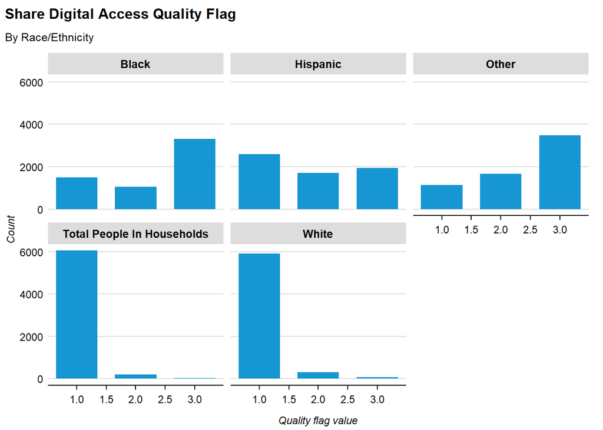

```r
plot_quality_flags(county_raceeth_digital_access) +
  labs(subtitle = "By Race/Ethnicity")
```

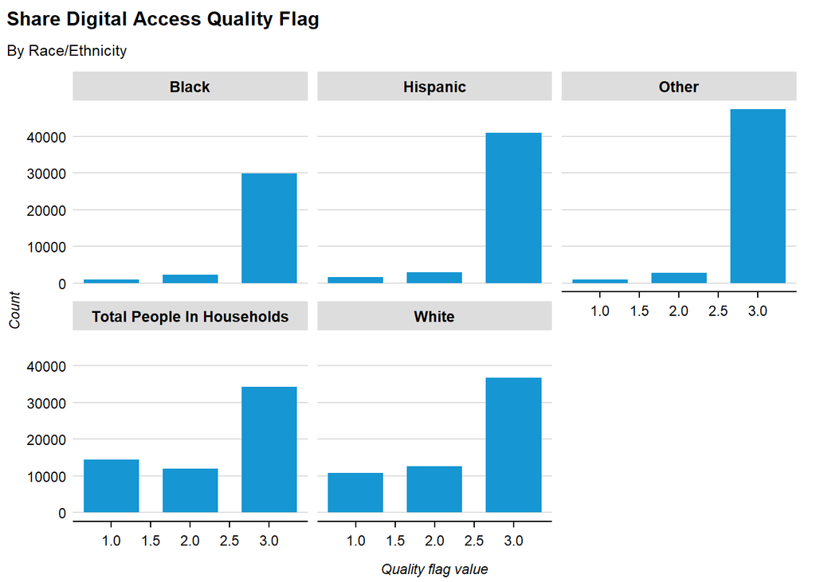

```r
plot_quality_flags(place_raceeth_digital_access) +
  labs(subtitle = "By Race/Ethnicity")
```

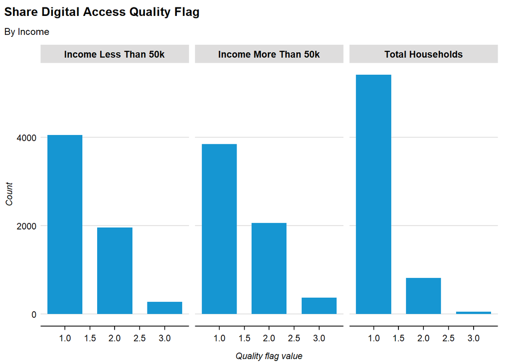

```r
plot_quality_flags(county_income_digital_access) +
  labs(subtitle = "By Income")
```

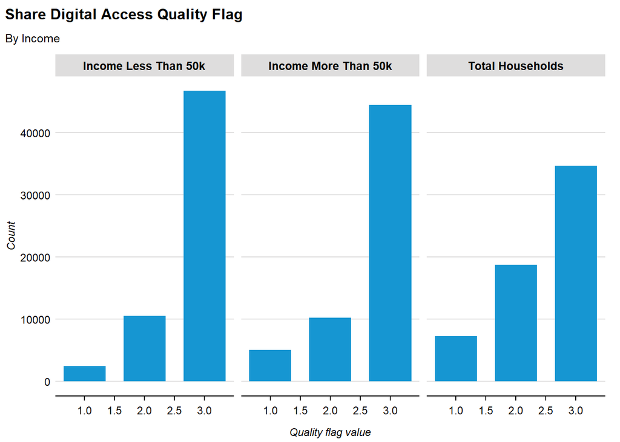

```r
plot_quality_flags(place_income_digital_access) +
  labs(subtitle = "By Income")
```

We also cap the lower bound at 0 and upper bound at 1

```r
cap_ci <- function(data) {
  data |>
    rowwise() |>
    mutate(
      across(
        contains("share_digital_access_lb"),
        ~ max(.x, 0, na.rm = TRUE)
      ),
      across(
        contains("share_digital_access_ub"),
        ~ min(.x, 1, na.rm = TRUE)
      )
    ) |>
    ungroup()
}

lst(
  county_overall_digital_access,
  place_overall_digital_access,
  county_raceeth_digital_access,
  place_raceeth_digital_access,
  county_income_digital_access,
  place_income_digital_access
) %>%
  map2(
    .x = names(.),
    .y = .,
    .f = ~ assign(
      x = .x,
      value = cap_ci(.y),
      envir = .GlobalEnv
    )
  )
```

```
[[1]]
# A tibble: 6,285 x 13
   geoid name                     year total_households total_households_digital
   <chr> <chr>                   <dbl>            <dbl>                    <dbl>
 1 01001 Autauga County, Alabama  2018            21115                    16549
 2 01001 Autauga County, Alabama  2021            21856                    18547
 3 01003 Baldwin County, Alabama  2018            78622                    61121
 4 01003 Baldwin County, Alabama  2021            87190                    76104
 5 01005 Barbour County, Alabama  2018             9186                     5490
 6 01005 Barbour County, Alabama  2021             9088                     5815
 7 01007 Bibb County, Alabama     2018             6840                     4455
 8 01007 Bibb County, Alabama     2021             7083                     5211
 9 01009 Blount County, Alabama   2018            20600                    13951
10 01009 Blount County, Alabama   2021            21300                    17026
# i 6,275 more rows
# i 8 more variables: moe_total_households <dbl>,
#   moe_total_households_digital <dbl>, total_households_digital_lb <dbl>,
#   total_households_digital_ub <dbl>,
#   share_digital_access_total_households <dbl>,
#   share_digital_access_lb_total_households <dbl>,
#   share_digital_access_ub_total_households <dbl>, ...

[[2]]
# A tibble: 61,481 x 13
   geoid   name                     year total_households total_households_dig~1
   <chr>   <chr>                   <dbl>            <dbl>                  <dbl>
 1 0100100 Abanda CDP, Alabama      2018               88                     26
 2 0100100 Abanda CDP, Alabama      2021               67                     67
 3 0100124 Abbeville city, Alabama  2018              993                    615
 4 0100124 Abbeville city, Alabama  2021              922                    758
 5 0100460 Adamsville city, Alaba~  2018             1472                   1068
 6 0100460 Adamsville city, Alaba~  2021             1490                    998
 7 0100484 Addison town, Alabama    2018              308                    193
 8 0100484 Addison town, Alabama    2021              296                    245
 9 0100676 Akron town, Alabama      2018              117                     51
10 0100676 Akron town, Alabama      2021               92                     61
# i 61,471 more rows
# i abbreviated name: 1: total_households_digital
# i 8 more variables: moe_total_households <dbl>,
#   moe_total_households_digital <dbl>, total_households_digital_lb <dbl>,
```

[output cut: 76 more lines]

```
 3  2018 0100124 Abbeville city, Alabama              993                  134.
 4  2021 0100124 Abbeville city, Alabama              922                  188.
 5  2018 0100460 Adamsville city, Alaba~             1472                  235.
 6  2021 0100460 Adamsville city, Alaba~             1490                  248.
 7  2018 0100484 Addison town, Alabama                308                   58.8
 8  2021 0100484 Addison town, Alabama                296                   73.1
 9  2018 0100676 Akron town, Alabama                  117                   32.1
10  2021 0100676 Akron town, Alabama                   92                   48.6
# i 61,471 more rows
# i abbreviated name: 1: moe_total_households_digital
# i 27 more variables: total_households_digital <dbl>,
#   income_less_than_50k <dbl>, moe_income_less_than_50k <dbl>,
#   income_more_than_50k <dbl>, moe_income_more_than_50k <dbl>,
#   income_less_than_50k_digital <dbl>, moe_income_less_than_50k_digital <dbl>,
#   income_more_than_50k_digital <dbl>, ...
```

```r
skim(county_overall_digital_access)
```

Data summary

| Name | county_overall_digital_ac… |
| --- | --- |
| Number of rows | 6285 |
| Number of columns | 13 |
| _______________________ |  |
| Column type frequency: |  |
| character | 2 |
| numeric | 11 |
| ________________________ |  |
| Group variables | None |

**Variable type: character**

| skim_variable | n_missing | complete_rate | min | max | empty | n_unique | whitespace |
| --- | --- | --- | --- | --- | --- | --- | --- |
| geoid | 0 | 1 | 5 | 5 | 0 | 3144 | 0 |
| name | 0 | 1 | 16 | 42 | 0 | 3144 | 0 |

**Variable type: numeric**

| skim_variable | n_missing | complete_rate | mean | sd | p0 | p25 | p50 | p75 | p100 | hist |
| --- | --- | --- | --- | --- | --- | --- | --- | --- | --- | --- |
| year | 0 | 1 | 2019.50 | 1.50 | 2018.00 | 2018.00 | 2021.00 | 2021.00 | 2021.00 | ▇▁▁▁▇ |
| total_households | 0 | 1 | 38781.40 | 117935.65 | 31.00 | 4165.00 | 9841.00 | 26056.00 | 3342811.00 | ▇▁▁▁▁ |
| total_households_digital | 0 | 1 | 32211.24 | 100728.17 | 20.00 | 2944.00 | 7302.00 | 20487.00 | 2949344.00 | ▇▁▁▁▁ |
| moe_total_households | 0 | 1 | 468.29 | 460.65 | 10.72 | 210.89 | 339.57 | 556.43 | 6592.51 | ▇▁▁▁▁ |
| moe_total_households_digital | 0 | 1 | 582.07 | 624.28 | 9.53 | 239.49 | 409.87 | 685.11 | 9975.15 | ▇▁▁▁▁ |
| total_households_digital_lb | 0 | 1 | 31629.17 | 100184.68 | -8.60 | 2692.49 | 6853.00 | 19882.23 | 2940341.11 | ▇▁▁▁▁ |
| total_households_digital_ub | 0 | 1 | 32793.31 | 101272.59 | 37.53 | 3183.02 | 7731.60 | 21094.26 | 2958346.89 | ▇▁▁▁▁ |
| share_digital_access_total_households | 0 | 1 | 0.76 | 0.10 | 0.25 | 0.70 | 0.77 | 0.83 | 0.98 | ▁▁▂▇▃ |
| share_digital_access_lb_total_households | 0 | 1 | 0.71 | 0.11 | 0.00 | 0.64 | 0.72 | 0.79 | 0.96 | ▁▁▂▇▅ |
| share_digital_access_ub_total_households | 0 | 1 | 0.80 | 0.09 | 0.30 | 0.75 | 0.81 | 0.86 | 1.00 | ▁▁▂▇▃ |
| share_digital_access_total_households_quality | 0 | 1 | 1.06 | 0.27 | 1.00 | 1.00 | 1.00 | 1.00 | 3.00 | ▇▁▁▁▁ |

```r
skim(county_raceeth_digital_access)
```

Data summary

| Name | county_raceeth_digital_ac… |
| --- | --- |
| Number of rows | 6285 |
| Number of columns | 53 |
| _______________________ |  |
| Column type frequency: |  |
| character | 2 |
| numeric | 51 |
| ________________________ |  |
| Group variables | None |

**Variable type: character**

| skim_variable | n_missing | complete_rate | min | max | empty | n_unique | whitespace |
| --- | --- | --- | --- | --- | --- | --- | --- |
| geoid | 0 | 1 | 5 | 5 | 0 | 3144 | 0 |
| name | 0 | 1 | 16 | 42 | 0 | 3144 | 0 |

**Variable type: numeric**

| skim_variable | n_missing | complete_rate | mean | sd | p0 | p25 | p50 | p75 | p100 | hist |
| --- | --- | --- | --- | --- | --- | --- | --- | --- | --- | --- |
| year | 0 | 1.00 | 2019.50 | 1.50 | 2018.00 | 2018.00 | 2021.00 | 2021.00 | 2021.00 | ▇▁▁▁▇ |
| white | 0 | 1.00 | 71517.17 | 190749.27 | 10.00 | 8444.00 | 20888.00 | 55847.00 | 5094576.00 | ▇▁▁▁▁ |
| black | 0 | 1.00 | 12536.07 | 54470.27 | 0.00 | 70.00 | 552.00 | 4927.00 | 1201026.00 | ▇▁▁▁▁ |
| other | 0 | 1.00 | 17252.99 | 108353.11 | 0.00 | 471.00 | 1412.00 | 5385.00 | 4778584.00 | ▇▁▁▁▁ |
| hispanic | 0 | 1.00 | 18489.45 | 125360.36 | 0.00 | 317.00 | 1009.00 | 4966.00 | 4845150.00 | ▇▁▁▁▁ |
| total_people_in_households | 0 | 1.00 | 101306.24 | 326295.98 | 38.00 | 10515.00 | 24783.00 | 65245.00 | 9920572.00 | ▇▁▁▁▁ |
| total_people_in_households_digital | 0 | 1.00 | 88231.16 | 288857.62 | 30.00 | 8028.00 | 19843.00 | 55332.00 | 8967688.00 | ▇▁▁▁▁ |
| white_digital | 0 | 1.00 | 62816.75 | 170380.71 | 8.00 | 6634.00 | 17007.00 | 47071.00 | 4335406.00 | ▇▁▁▁▁ |
| black_digital | 0 | 1.00 | 10059.43 | 44338.08 | 0.00 | 52.00 | 426.00 | 3488.00 | 1000639.00 | ▇▁▁▁▁ |
| other_digital | 0 | 1.00 | 15354.98 | 97474.75 | 0.00 | 365.00 | 1149.00 | 4565.00 | 4385196.00 | ▇▁▁▁▁ |
| hispanic_digital | 0 | 1.00 | 15555.78 | 106053.84 | 0.00 | 245.00 | 810.00 | 4011.00 | 4317483.00 | ▇▁▁▁▁ |
| moe_white | 0 | 1.00 | 648.05 | 1099.11 | 3.57 | 166.81 | 314.55 | 660.09 | 19162.72 | ▇▁▁▁▁ |
| moe_black | 0 | 1.00 | 330.30 | 514.43 | 2.38 | 54.81 | 158.47 | 365.79 | 5946.72 | ▇▁▁▁▁ |
| moe_other | 0 | 1.00 | 485.66 | 1060.91 | 2.38 | 54.81 | 170.38 | 465.87 | 22133.11 | ▇▁▁▁▁ |
| moe_hispanic | 0 | 1.00 | 97.03 | 153.56 | 1.19 | 19.06 | 48.85 | 115.57 | 2248.34 | ▇▁▁▁▁ |
| moe_total_people_in_households | 2 | 1.00 | 332.80 | 399.81 | 1.19 | 109.62 | 203.74 | 397.36 | 5034.04 | ▇▁▁▁▁ |
| moe_total_people_in_households_digital | 0 | 1.00 | 1135.05 | 1276.32 | 14.30 | 428.94 | 794.72 | 1349.96 | 21525.45 | ▇▁▁▁▁ |
| moe_white_digital | 0 | 1.00 | 1068.73 | 1286.75 | 3.57 | 392.00 | 718.47 | 1261.79 | 24349.28 | ▇▁▁▁▁ |
| moe_black_digital | 0 | 1.00 | 461.53 | 767.23 | 2.38 | 50.04 | 185.87 | 544.51 | 9357.96 | ▇▁▁▁▁ |
| moe_other_digital | 0 | 1.00 | 770.65 | 1440.21 | 18.57 | 158.64 | 325.98 | 753.40 | 28978.50 | ▇▁▁▁▁ |
| moe_hispanic_digital | 0 | 1.00 | 423.37 | 846.85 | 1.19 | 66.72 | 165.62 | 426.55 | 16021.96 | ▇▁▁▁▁ |
| total_people_in_households_digital_lb | 0 | 1.00 | 87096.11 | 287791.07 | -25.26 | 7558.55 | 19047.11 | 53881.32 | 8951482.55 | ▇▁▁▁▁ |
| total_people_in_households_digital_ub | 0 | 1.00 | 89366.21 | 289925.86 | 51.45 | 8534.34 | 20733.19 | 56608.34 | 8983893.45 | ▇▁▁▁▁ |
| other_digital_lb | 0 | 1.00 | 14584.34 | 96337.18 | -348.32 | 189.78 | 815.52 | 3794.20 | 4356217.50 | ▇▁▁▁▁ |
| other_digital_ub | 0 | 1.00 | 16125.63 | 98620.24 | 23.08 | 538.79 | 1482.79 | 5336.74 | 4414174.50 | ▇▁▁▁▁ |
| black_digital_lb | 0 | 1.00 | 9597.90 | 43693.39 | -308.19 | -2.34 | 231.51 | 2964.34 | 993370.91 | ▇▁▁▁▁ |
| black_digital_ub | 0 | 1.00 | 10520.95 | 44986.61 | 3.38 | 105.85 | 615.04 | 4042.94 | 1007907.09 | ▇▁▁▁▁ |
| hispanic_digital_lb | 0 | 1.00 | 15132.41 | 105392.33 | -1113.21 | 150.38 | 655.34 | 3607.28 | 4306279.43 | ▇▁▁▁▁ |
| hispanic_digital_ub | 0 | 1.00 | 15979.14 | 106717.96 | 3.38 | 333.51 | 973.45 | 4458.79 | 4328686.57 | ▇▁▁▁▁ |
| white_digital_lb | 0 | 1.00 | 61748.03 | 169246.93 | -222.43 | 6140.87 | 16240.43 | 45957.49 | 4311056.72 | ▇▁▁▁▁ |
| white_digital_ub | 0 | 1.00 | 63885.48 | 171516.66 | 11.57 | 7109.91 | 17786.62 | 48169.62 | 4359755.28 | ▇▁▁▁▁ |
| share_digital_access_total_people_in_households | 0 | 1.00 | 0.81 | 0.09 | 0.27 | 0.77 | 0.83 | 0.88 | 0.99 | ▁▁▂▇▆ |
| share_digital_access_lb_total_people_in_households | 0 | 1.00 | 0.78 | 0.11 | 0.00 | 0.72 | 0.79 | 0.85 | 0.98 | ▁▁▁▆▇ |
| share_digital_access_ub_total_people_in_households | 0 | 1.00 | 0.85 | 0.08 | 0.32 | 0.81 | 0.86 | 0.90 | 1.00 | ▁▁▁▇▇ |
| share_digital_access_other | 8 | 1.00 | 0.82 | 0.14 | 0.00 | 0.77 | 0.86 | 0.92 | 1.00 | ▁▁▁▃▇ |
| share_digital_access_lb_other | 0 | 1.00 | 0.55 | 0.24 | 0.00 | 0.42 | 0.60 | 0.73 | 0.95 | ▂▂▅▇▅ |
| share_digital_access_ub_other | 0 | 1.00 | 0.96 | 0.08 | 0.28 | 0.96 | 1.00 | 1.00 | 1.00 | ▁▁▁▁▇ |
| share_digital_access_black | 441 | 0.93 | 0.77 | 0.21 | 0.00 | 0.67 | 0.81 | 0.94 | 1.00 | ▁▁▂▅▇ |
| share_digital_access_lb_black | 0 | 1.00 | 0.38 | 0.30 | 0.00 | 0.00 | 0.43 | 0.65 | 0.95 | ▇▂▅▆▃ |
| share_digital_access_ub_black | 0 | 1.00 | 0.91 | 0.14 | 0.06 | 0.85 | 1.00 | 1.00 | 1.00 | ▁▁▁▂▇ |
| share_digital_access_hispanic | 44 | 0.99 | 0.80 | 0.17 | 0.00 | 0.73 | 0.84 | 0.92 | 1.00 | ▁▁▁▃▇ |
| share_digital_access_lb_hispanic | 0 | 1.00 | 0.60 | 0.29 | 0.00 | 0.44 | 0.69 | 0.82 | 1.00 | ▃▂▃▇▇ |
| share_digital_access_ub_hispanic | 0 | 1.00 | 0.93 | 0.10 | 0.06 | 0.89 | 0.97 | 1.00 | 1.00 | ▁▁▁▁▇ |
| share_digital_access_white | 0 | 1.00 | 0.83 | 0.08 | 0.28 | 0.78 | 0.84 | 0.88 | 1.00 | ▁▁▁▇▆ |
| share_digital_access_lb_white | 0 | 1.00 | 0.78 | 0.10 | 0.00 | 0.73 | 0.80 | 0.86 | 0.97 | ▁▁▁▅▇ |
| share_digital_access_ub_white | 0 | 1.00 | 0.87 | 0.07 | 0.34 | 0.83 | 0.87 | 0.91 | 1.00 | ▁▁▁▆▇ |
| share_digital_access_total_people_in_households_quality | 0 | 1.00 | 1.04 | 0.23 | 1.00 | 1.00 | 1.00 | 1.00 | 3.00 | ▇▁▁▁▁ |
| share_digital_access_other_quality | 8 | 1.00 | 2.38 | 0.77 | 1.00 | 2.00 | 3.00 | 3.00 | 3.00 | ▂▁▃▁▇ |
| share_digital_access_black_quality | 441 | 0.93 | 2.31 | 0.85 | 1.00 | 1.00 | 3.00 | 3.00 | 3.00 | ▃▁▂▁▇ |
| share_digital_access_hispanic_quality | 44 | 0.99 | 1.90 | 0.85 | 1.00 | 1.00 | 2.00 | 3.00 | 3.00 | ▇▁▅▁▆ |
| share_digital_access_white_quality | 0 | 1.00 | 1.07 | 0.30 | 1.00 | 1.00 | 1.00 | 1.00 | 3.00 | ▇▁▁▁▁ |

```r
skim(county_income_digital_access)
```

Data summary

| Name | county_income_digital_acc… |
| --- | --- |
| Number of rows | 6285 |
| Number of columns | 32 |
| _______________________ |  |
| Column type frequency: |  |
| character | 2 |
| numeric | 30 |
| ________________________ |  |
| Group variables | None |

**Variable type: character**

| skim_variable | n_missing | complete_rate | min | max | empty | n_unique | whitespace |
| --- | --- | --- | --- | --- | --- | --- | --- |
| geoid | 0 | 1 | 5 | 5 | 0 | 3144 | 0 |
| name | 0 | 1 | 16 | 42 | 0 | 3144 | 0 |

**Variable type: numeric**

| skim_variable | n_missing | complete_rate | mean | sd | p0 | p25 | p50 | p75 | p100 | hist |
| --- | --- | --- | --- | --- | --- | --- | --- | --- | --- | --- |
| year | 0 | 1 | 2019.50 | 1.50 | 2018.00 | 2018.00 | 2021.00 | 2021.00 | 2021.00 | ▇▁▁▁▇ |
| total_households | 1 | 1 | 38785.60 | 117944.57 | 31.00 | 4164.00 | 9838.00 | 26057.75 | 3342811.00 | ▇▁▁▁▁ |
| moe_total_households_digital | 1 | 1 | 926.96 | 1052.38 | 21.05 | 337.76 | 600.61 | 1086.19 | 14993.36 | ▇▁▁▁▁ |
| total_households_digital | 1 | 1 | 32486.87 | 101509.07 | 24.00 | 2972.75 | 7359.50 | 20681.00 | 2971249.00 | ▇▁▁▁▁ |
| income_less_than_50k | 1 | 1 | 15289.60 | 44227.68 | 8.00 | 2086.50 | 4831.50 | 11684.00 | 1326414.00 | ▇▁▁▁▁ |
| moe_income_less_than_50k | 1 | 1 | 742.31 | 773.19 | 7.15 | 296.03 | 521.16 | 894.54 | 10245.46 | ▇▁▁▁▁ |
| income_more_than_50k | 1 | 1 | 23496.00 | 75236.99 | 14.00 | 2010.00 | 4890.00 | 14168.75 | 2209587.00 | ▇▁▁▁▁ |
| moe_income_more_than_50k | 1 | 1 | 709.53 | 820.46 | 10.98 | 256.51 | 454.49 | 821.66 | 11943.86 | ▇▁▁▁▁ |
| income_less_than_50k_digital | 1 | 1 | 10708.63 | 31848.51 | 3.00 | 1223.50 | 3011.50 | 7820.50 | 897141.00 | ▇▁▁▁▁ |
| moe_income_less_than_50k_digital | 1 | 1 | 622.63 | 680.42 | 14.15 | 231.78 | 418.73 | 741.09 | 9193.60 | ▇▁▁▁▁ |
| income_more_than_50k_digital | 1 | 1 | 21778.24 | 70632.20 | 11.00 | 1714.00 | 4298.00 | 12901.25 | 2092776.00 | ▇▁▁▁▁ |
| moe_income_more_than_50k_digital | 1 | 1 | 682.20 | 806.68 | 8.59 | 239.55 | 428.44 | 792.75 | 11843.93 | ▇▁▁▁▁ |
| total_households_digital_lb | 1 | 1 | 31559.91 | 100602.20 | -15.96 | 2626.16 | 6753.81 | 19692.98 | 2956255.64 | ▇▁▁▁▁ |
| total_households_digital_ub | 1 | 1 | 33413.83 | 102418.73 | 49.05 | 3324.48 | 7972.95 | 21719.97 | 2986242.36 | ▇▁▁▁▁ |
| income_less_than_50k_digital_lb | 1 | 1 | 10086.00 | 31274.53 | -24.25 | 985.29 | 2579.91 | 7097.62 | 890662.26 | ▇▁▁▁▁ |
| income_less_than_50k_digital_ub | 1 | 1 | 11331.25 | 32426.61 | 25.21 | 1457.87 | 3432.91 | 8547.01 | 903619.74 | ▇▁▁▁▁ |
| income_more_than_50k_digital_lb | 1 | 1 | 21096.04 | 69932.65 | -10.45 | 1450.97 | 3860.86 | 12150.78 | 2080932.07 | ▇▁▁▁▁ |
| income_more_than_50k_digital_ub | 1 | 1 | 22460.44 | 71334.01 | 29.19 | 1948.04 | 4711.88 | 13684.89 | 2104619.93 | ▇▁▁▁▁ |
| share_digital_access_total_households | 1 | 1 | 0.77 | 0.09 | 0.26 | 0.71 | 0.78 | 0.83 | 0.98 | ▁▁▂▇▃ |
| share_digital_access_lb_total_households | 0 | 1 | 0.70 | 0.11 | 0.00 | 0.63 | 0.71 | 0.78 | 0.95 | ▁▁▂▇▅ |
| share_digital_access_ub_total_households | 0 | 1 | 0.83 | 0.09 | 0.31 | 0.78 | 0.84 | 0.89 | 1.00 | ▁▁▂▇▆ |
| share_digital_access_income_less_than_50k | 1 | 1 | 0.65 | 0.10 | 0.20 | 0.58 | 0.65 | 0.72 | 1.00 | ▁▂▇▆▁ |
| share_digital_access_lb_income_less_than_50k | 0 | 1 | 0.55 | 0.12 | 0.00 | 0.48 | 0.56 | 0.63 | 0.84 | ▁▁▅▇▂ |
| share_digital_access_ub_income_less_than_50k | 0 | 1 | 0.74 | 0.11 | 0.26 | 0.67 | 0.74 | 0.81 | 1.00 | ▁▁▅▇▂ |
| share_digital_access_income_more_than_50k | 1 | 1 | 0.88 | 0.06 | 0.40 | 0.85 | 0.89 | 0.92 | 1.00 | ▁▁▁▅▇ |
| share_digital_access_lb_income_more_than_50k | 0 | 1 | 0.79 | 0.10 | 0.00 | 0.73 | 0.80 | 0.86 | 0.96 | ▁▁▁▅▇ |
| share_digital_access_ub_income_more_than_50k | 0 | 1 | 0.96 | 0.04 | 0.56 | 0.94 | 0.97 | 1.00 | 1.00 | ▁▁▁▁▇ |
| share_digital_access_total_households_quality | 1 | 1 | 1.15 | 0.38 | 1.00 | 1.00 | 1.00 | 1.00 | 3.00 | ▇▁▁▁▁ |
| share_digital_access_income_less_than_50k_quality | 1 | 1 | 1.40 | 0.57 | 1.00 | 1.00 | 1.00 | 2.00 | 3.00 | ▇▁▃▁▁ |
| share_digital_access_income_more_than_50k_quality | 1 | 1 | 1.45 | 0.60 | 1.00 | 1.00 | 1.00 | 2.00 | 3.00 | ▇▁▅▁▁ |

```r
skim(place_overall_digital_access)
```

Data summary

| Name | place_overall_digital_acc… |
| --- | --- |
| Number of rows | 61481 |
| Number of columns | 13 |
| _______________________ |  |
| Column type frequency: |  |
| character | 2 |
| numeric | 11 |
| ________________________ |  |
| Group variables | None |

**Variable type: character**

| skim_variable | n_missing | complete_rate | min | max | empty | n_unique | whitespace |
| --- | --- | --- | --- | --- | --- | --- | --- |
| geoid | 0 | 1 | 7 | 7 | 0 | 32005 | 0 |
| name | 0 | 1 | 12 | 66 | 0 | 32073 | 0 |

**Variable type: numeric**

| skim_variable | n_missing | complete_rate | mean | sd | p0 | p25 | p50 | p75 | p100 | hist |
| --- | --- | --- | --- | --- | --- | --- | --- | --- | --- | --- |
| year | 0 | 1.00 | 2019.56 | 1.50 | 2018.00 | 2018.00 | 2021.00 | 2021.00 | 2021.00 | ▇▁▁▁▇ |
| total_households | 0 | 1.00 | 3008.40 | 25365.34 | 0.00 | 120.00 | 399.00 | 1498.00 | 3250657.00 | ▇▁▁▁▁ |
| total_households_digital | 0 | 1.00 | 2502.55 | 20918.17 | 0.00 | 86.00 | 297.00 | 1210.00 | 2765573.00 | ▇▁▁▁▁ |
| moe_total_households | 0 | 1.00 | 160.58 | 206.96 | 1.19 | 45.28 | 96.51 | 198.98 | 8359.49 | ▇▁▁▁▁ |
| moe_total_households_digital | 0 | 1.00 | 158.12 | 228.76 | 1.19 | 38.13 | 86.98 | 195.40 | 11961.36 | ▇▁▁▁▁ |
| total_households_digital_lb | 0 | 1.00 | 2344.43 | 20759.59 | -127.26 | 41.60 | 208.36 | 1014.74 | 2753795.13 | ▇▁▁▁▁ |
| total_households_digital_ub | 0 | 1.00 | 2660.67 | 21078.04 | 2.19 | 128.04 | 388.91 | 1405.21 | 2777350.87 | ▇▁▁▁▁ |
| share_digital_access_total_households | 766 | 0.99 | 0.76 | 0.17 | 0.00 | 0.68 | 0.79 | 0.88 | 1.00 | ▁▁▂▆▇ |
| share_digital_access_lb_total_households | 0 | 1.00 | 0.50 | 0.25 | 0.00 | 0.35 | 0.55 | 0.70 | 0.97 | ▃▃▇▇▃ |
| share_digital_access_ub_total_households | 0 | 1.00 | 0.92 | 0.12 | 0.09 | 0.87 | 0.98 | 1.00 | 1.00 | ▁▁▁▁▇ |
| share_digital_access_total_households_quality | 766 | 0.99 | 2.28 | 0.79 | 1.00 | 2.00 | 2.00 | 3.00 | 3.00 | ▃▁▅▁▇ |

```r
skim(place_raceeth_digital_access)
```

Data summary

| Name | place_raceeth_digital_acc… |
| --- | --- |
| Number of rows | 61481 |
| Number of columns | 53 |
| _______________________ |  |
| Column type frequency: |  |
| character | 2 |
| numeric | 51 |
| ________________________ |  |
| Group variables | None |

**Variable type: character**

| skim_variable | n_missing | complete_rate | min | max | empty | n_unique | whitespace |
| --- | --- | --- | --- | --- | --- | --- | --- |
| geoid | 0 | 1 | 7 | 7 | 0 | 32005 | 0 |
| name | 0 | 1 | 12 | 66 | 0 | 32073 | 0 |

**Variable type: numeric**

| skim_variable | n_missing | complete_rate | mean | sd | p0 | p25 | p50 | p75 | p100 | hist |
| --- | --- | --- | --- | --- | --- | --- | --- | --- | --- | --- |
| year | 0 | 1.00 | 2019.56 | 1.50 | 2018.00 | 2018.00 | 2021.00 | 2021.00 | 2021.00 | ▇▁▁▁▇ |
| white | 0 | 1.00 | 5191.77 | 32406.88 | 0.00 | 235.00 | 809.00 | 2977.00 | 3521240.00 | ▇▁▁▁▁ |
| black | 0 | 1.00 | 1085.49 | 15456.08 | 0.00 | 0.00 | 4.00 | 138.00 | 1986320.00 | ▇▁▁▁▁ |
| other | 0 | 1.00 | 1548.55 | 22088.03 | 0.00 | 7.00 | 57.00 | 357.00 | 3176190.00 | ▇▁▁▁▁ |
| hispanic | 0 | 1.00 | 1721.29 | 22643.07 | 0.00 | 0.00 | 35.00 | 306.00 | 2476224.00 | ▇▁▁▁▁ |
| total_people_in_households | 0 | 1.00 | 7825.82 | 66318.18 | 0.00 | 302.00 | 1008.00 | 3823.00 | 8550333.00 | ▇▁▁▁▁ |
| total_people_in_households_digital | 0 | 1.00 | 6825.56 | 57014.29 | 0.00 | 233.00 | 815.00 | 3262.00 | 7569692.00 | ▇▁▁▁▁ |
| white_digital | 0 | 1.00 | 4580.25 | 28212.72 | 0.00 | 183.00 | 663.00 | 2559.00 | 2992703.00 | ▇▁▁▁▁ |
| black_digital | 0 | 1.00 | 868.14 | 12420.67 | 0.00 | 0.00 | 2.00 | 106.00 | 1714285.00 | ▇▁▁▁▁ |
| other_digital | 0 | 1.00 | 1377.17 | 19404.16 | 0.00 | 4.00 | 45.00 | 299.00 | 2862704.00 | ▇▁▁▁▁ |
| hispanic_digital | 0 | 1.00 | 1438.64 | 18663.86 | 0.00 | 0.00 | 28.00 | 253.00 | 2153167.00 | ▇▁▁▁▁ |
| moe_white | 0 | 1.00 | 358.98 | 481.03 | 1.19 | 100.09 | 213.28 | 428.94 | 15060.43 | ▇▁▁▁▁ |
| moe_black | 0 | 1.00 | 144.34 | 319.83 | 2.38 | 13.11 | 15.49 | 129.87 | 10114.55 | ▇▁▁▁▁ |
| moe_other | 0 | 1.00 | 124.36 | 351.42 | 2.38 | 13.11 | 15.49 | 77.45 | 18689.70 | ▇▁▁▁▁ |
| moe_hispanic | 0 | 1.00 | 196.32 | 382.14 | 1.19 | 14.30 | 45.28 | 210.89 | 12299.74 | ▇▁▁▁▁ |
| moe_total_people_in_households | 2 | 1.00 | 282.67 | 350.86 | 1.19 | 84.60 | 175.15 | 340.77 | 6061.11 | ▇▁▁▁▁ |
| moe_total_people_in_households_digital | 0 | 1.00 | 370.60 | 486.36 | 1.19 | 107.23 | 229.96 | 450.38 | 20862.98 | ▇▁▁▁▁ |
| moe_white_digital | 0 | 1.00 | 371.60 | 508.58 | 1.19 | 92.94 | 216.85 | 455.15 | 17524.43 | ▇▁▁▁▁ |
| moe_black_digital | 0 | 1.00 | 142.72 | 343.75 | 2.38 | 13.11 | 15.49 | 113.19 | 13393.53 | ▇▁▁▁▁ |
| moe_other_digital | 0 | 1.00 | 230.34 | 507.78 | 13.48 | 31.97 | 56.16 | 208.93 | 23650.18 | ▇▁▁▁▁ |
| moe_hispanic_digital | 0 | 1.00 | 197.73 | 422.88 | 1.19 | 14.30 | 38.13 | 197.79 | 13550.81 | ▇▁▁▁▁ |
| total_people_in_households_digital_lb | 0 | 1.00 | 6454.96 | 56728.70 | -372.79 | 105.74 | 542.00 | 2809.23 | 7550653.19 | ▇▁▁▁▁ |
| total_people_in_households_digital_ub | 0 | 1.00 | 7196.16 | 57302.59 | 2.19 | 357.09 | 1090.62 | 3719.74 | 7588730.81 | ▇▁▁▁▁ |
| other_digital_lb | 0 | 1.00 | 1146.83 | 19099.93 | -569.36 | -26.64 | -13.89 | 85.91 | 2839053.82 | ▇▁▁▁▁ |
| other_digital_ub | 0 | 1.00 | 1607.52 | 19716.77 | 19.81 | 34.64 | 103.62 | 514.21 | 2886354.18 | ▇▁▁▁▁ |
| black_digital_lb | 0 | 1.00 | 725.43 | 12223.97 | -530.87 | -14.30 | -11.91 | -1.77 | 1700891.47 | ▇▁▁▁▁ |
| black_digital_ub | 0 | 1.00 | 1010.86 | 12623.67 | 3.38 | 13.11 | 15.49 | 224.15 | 1727678.53 | ▇▁▁▁▁ |
| hispanic_digital_lb | 0 | 1.00 | 1240.91 | 18420.59 | -557.19 | -14.30 | -8.06 | 50.40 | 2141244.96 | ▇▁▁▁▁ |
| hispanic_digital_ub | 0 | 1.00 | 1636.38 | 18913.46 | 2.19 | 14.30 | 67.51 | 460.00 | 2165089.04 | ▇▁▁▁▁ |
| white_digital_lb | 0 | 1.00 | 4208.64 | 27873.86 | -307.64 | 72.06 | 427.74 | 2118.47 | 2975178.57 | ▇▁▁▁▁ |
| white_digital_ub | 0 | 1.00 | 4951.85 | 28556.61 | 2.19 | 287.94 | 902.77 | 3010.45 | 3010227.43 | ▇▁▁▁▁ |
| share_digital_access_total_people_in_households | 766 | 0.99 | 0.82 | 0.16 | 0.00 | 0.76 | 0.85 | 0.92 | 1.00 | ▁▁▁▃▇ |
| share_digital_access_lb_total_people_in_households | 0 | 1.00 | 0.53 | 0.27 | 0.00 | 0.36 | 0.58 | 0.75 | 1.00 | ▅▃▇▇▅ |
| share_digital_access_ub_total_people_in_households | 0 | 1.00 | 0.95 | 0.10 | 0.02 | 0.94 | 1.00 | 1.00 | 1.00 | ▁▁▁▁▇ |
| share_digital_access_other | 10437 | 0.83 | 0.84 | 0.25 | 0.00 | 0.79 | 0.95 | 1.00 | 1.00 | ▁▁▁▂▇ |
| share_digital_access_lb_other | 0 | 1.00 | 0.16 | 0.25 | 0.00 | 0.00 | 0.00 | 0.29 | 0.95 | ▇▁▁▁▁ |
| share_digital_access_ub_other | 0 | 1.00 | 0.99 | 0.07 | 0.05 | 1.00 | 1.00 | 1.00 | 1.00 | ▁▁▁▁▇ |
| share_digital_access_black | 28347 | 0.54 | 0.80 | 0.28 | 0.00 | 0.70 | 0.93 | 1.00 | 1.00 | ▁▁▁▂▇ |
| share_digital_access_lb_black | 0 | 1.00 | 0.09 | 0.20 | 0.00 | 0.00 | 0.00 | 0.00 | 0.94 | ▇▁▁▁▁ |
| share_digital_access_ub_black | 0 | 1.00 | 0.98 | 0.10 | 0.03 | 1.00 | 1.00 | 1.00 | 1.00 | ▁▁▁▁▇ |
| share_digital_access_hispanic | 16079 | 0.74 | 0.83 | 0.26 | 0.00 | 0.77 | 0.96 | 1.00 | 1.00 | ▁▁▁▂▇ |
| share_digital_access_lb_hispanic | 0 | 1.00 | 0.14 | 0.24 | 0.00 | 0.00 | 0.00 | 0.21 | 0.98 | ▇▁▁▁▁ |
| share_digital_access_ub_hispanic | 0 | 1.00 | 0.97 | 0.11 | 0.01 | 1.00 | 1.00 | 1.00 | 1.00 | ▁▁▁▁▇ |
| share_digital_access_white | 1298 | 0.98 | 0.82 | 0.16 | 0.00 | 0.77 | 0.86 | 0.93 | 1.00 | ▁▁▁▃▇ |
| share_digital_access_lb_white | 0 | 1.00 | 0.51 | 0.28 | 0.00 | 0.32 | 0.56 | 0.73 | 0.98 | ▅▃▆▇▅ |
| share_digital_access_ub_white | 0 | 1.00 | 0.96 | 0.09 | 0.02 | 0.97 | 1.00 | 1.00 | 1.00 | ▁▁▁▁▇ |
| share_digital_access_total_people_in_households_quality | 766 | 0.99 | 2.33 | 0.83 | 1.00 | 2.00 | 3.00 | 3.00 | 3.00 | ▃▁▃▁▇ |
| share_digital_access_other_quality | 10437 | 0.83 | 2.91 | 0.35 | 1.00 | 3.00 | 3.00 | 3.00 | 3.00 | ▁▁▁▁▇ |
| share_digital_access_black_quality | 28347 | 0.54 | 2.87 | 0.42 | 1.00 | 3.00 | 3.00 | 3.00 | 3.00 | ▁▁▁▁▇ |
| share_digital_access_hispanic_quality | 16079 | 0.74 | 2.87 | 0.43 | 1.00 | 3.00 | 3.00 | 3.00 | 3.00 | ▁▁▁▁▇ |
| share_digital_access_white_quality | 1298 | 0.98 | 2.43 | 0.78 | 1.00 | 2.00 | 3.00 | 3.00 | 3.00 | ▂▁▃▁▇ |

```r
skim(place_income_digital_access)
```

Data summary

| Name | place_income_digital_acce… |
| --- | --- |
| Number of rows | 61481 |
| Number of columns | 32 |
| _______________________ |  |
| Column type frequency: |  |
| character | 2 |
| numeric | 30 |
| ________________________ |  |
| Group variables | None |

**Variable type: character**

| skim_variable | n_missing | complete_rate | min | max | empty | n_unique | whitespace |
| --- | --- | --- | --- | --- | --- | --- | --- |
| geoid | 0 | 1 | 7 | 7 | 0 | 32005 | 0 |
| name | 0 | 1 | 12 | 66 | 0 | 32073 | 0 |

**Variable type: numeric**

| skim_variable | n_missing | complete_rate | mean | sd | p0 | p25 | p50 | p75 | p100 | hist |
| --- | --- | --- | --- | --- | --- | --- | --- | --- | --- | --- |
| year | 0 | 1.00 | 2019.56 | 1.50 | 2018.00 | 2018.00 | 2021.00 | 2021.00 | 2021.00 | ▇▁▁▁▇ |
| total_households | 34 | 1.00 | 3009.91 | 25372.27 | 0.00 | 120.00 | 399.00 | 1499.00 | 3250657.00 | ▇▁▁▁▁ |
| moe_total_households_digital | 34 | 1.00 | 214.90 | 338.73 | 7.44 | 43.92 | 98.38 | 261.55 | 17226.67 | ▇▁▁▁▁ |
| total_households_digital | 34 | 1.00 | 2526.26 | 21147.08 | 0.00 | 87.00 | 302.00 | 1223.00 | 2800947.00 | ▇▁▁▁▁ |
| income_less_than_50k | 34 | 1.00 | 1229.67 | 10635.00 | 0.00 | 55.00 | 176.00 | 612.00 | 1363016.00 | ▇▁▁▁▁ |
| moe_income_less_than_50k | 34 | 1.00 | 167.06 | 263.00 | 6.08 | 34.68 | 78.27 | 200.85 | 12926.99 | ▇▁▁▁▁ |
| income_more_than_50k | 34 | 1.00 | 1780.24 | 14965.98 | 0.00 | 54.00 | 195.00 | 835.00 | 2011251.00 | ▇▁▁▁▁ |
| moe_income_more_than_50k | 34 | 1.00 | 164.40 | 260.12 | 3.37 | 31.97 | 75.40 | 201.13 | 13037.34 | ▇▁▁▁▁ |
| income_less_than_50k_digital | 34 | 1.00 | 868.56 | 7393.37 | 0.00 | 33.00 | 113.00 | 413.00 | 912792.00 | ▇▁▁▁▁ |
| moe_income_less_than_50k_digital | 34 | 1.00 | 140.79 | 227.52 | 4.77 | 29.48 | 61.67 | 165.83 | 11045.34 | ▇▁▁▁▁ |
| income_more_than_50k_digital | 34 | 1.00 | 1657.70 | 13895.98 | 0.00 | 46.00 | 172.00 | 766.00 | 1888155.00 | ▇▁▁▁▁ |
| moe_income_more_than_50k_digital | 34 | 1.00 | 157.80 | 253.84 | 3.37 | 29.09 | 70.39 | 192.93 | 13219.62 | ▇▁▁▁▁ |
| total_households_digital_lb | 34 | 1.00 | 2311.35 | 20914.81 | -127.34 | 37.78 | 202.66 | 958.89 | 2783720.33 | ▇▁▁▁▁ |
| total_households_digital_ub | 34 | 1.00 | 2741.16 | 21382.18 | 14.44 | 134.20 | 404.16 | 1491.13 | 2818173.67 | ▇▁▁▁▁ |
| income_less_than_50k_digital_lb | 34 | 1.00 | 727.77 | 7238.02 | -156.38 | 2.41 | 50.81 | 252.16 | 901746.66 | ▇▁▁▁▁ |
| income_less_than_50k_digital_ub | 34 | 1.00 | 1009.34 | 7552.38 | 8.77 | 62.19 | 177.05 | 578.54 | 923837.34 | ▇▁▁▁▁ |
| income_more_than_50k_digital_lb | 34 | 1.00 | 1499.91 | 13722.27 | -125.99 | 12.45 | 99.88 | 575.26 | 1874935.38 | ▇▁▁▁▁ |
| income_more_than_50k_digital_ub | 34 | 1.00 | 1815.50 | 14072.12 | 5.37 | 77.72 | 244.76 | 960.69 | 1901374.62 | ▇▁▁▁▁ |
| share_digital_access_total_households | 800 | 0.99 | 0.77 | 0.17 | 0.00 | 0.69 | 0.80 | 0.89 | 1.00 | ▁▁▂▆▇ |
| share_digital_access_lb_total_households | 0 | 1.00 | 0.47 | 0.26 | 0.00 | 0.31 | 0.53 | 0.67 | 0.96 | ▅▃▇▇▃ |
| share_digital_access_ub_total_households | 0 | 1.00 | 0.94 | 0.10 | 0.14 | 0.92 | 1.00 | 1.00 | 1.00 | ▁▁▁▁▇ |
| share_digital_access_income_less_than_50k | 1783 | 0.97 | 0.66 | 0.20 | 0.00 | 0.56 | 0.68 | 0.79 | 1.00 | ▁▁▅▇▅ |
| share_digital_access_lb_income_less_than_50k | 0 | 1.00 | 0.29 | 0.22 | 0.00 | 0.04 | 0.31 | 0.46 | 0.83 | ▇▅▇▃▁ |
| share_digital_access_ub_income_less_than_50k | 0 | 1.00 | 0.91 | 0.13 | 0.09 | 0.84 | 1.00 | 1.00 | 1.00 | ▁▁▁▂▇ |
| share_digital_access_income_more_than_50k | 1831 | 0.97 | 0.88 | 0.14 | 0.00 | 0.85 | 0.92 | 0.97 | 1.00 | ▁▁▁▁▇ |
| share_digital_access_lb_income_more_than_50k | 0 | 1.00 | 0.48 | 0.29 | 0.00 | 0.25 | 0.54 | 0.72 | 0.96 | ▆▃▆▇▅ |
| share_digital_access_ub_income_more_than_50k | 0 | 1.00 | 0.99 | 0.04 | 0.14 | 1.00 | 1.00 | 1.00 | 1.00 | ▁▁▁▁▇ |
| share_digital_access_total_households_quality | 800 | 0.99 | 2.45 | 0.70 | 1.00 | 2.00 | 3.00 | 3.00 | 3.00 | ▂▁▅▁▇ |
| share_digital_access_income_less_than_50k_quality | 1783 | 0.97 | 2.74 | 0.52 | 1.00 | 3.00 | 3.00 | 3.00 | 3.00 | ▁▁▂▁▇ |
| share_digital_access_income_more_than_50k_quality | 1831 | 0.97 | 2.66 | 0.63 | 1.00 | 2.00 | 3.00 | 3.00 | 3.00 | ▁▁▂▁▇ |

# Prepare the data for saving & export final Metrics files

```r
# Read final County or Places population file to isolate data needed for each geography
#
# This function also cleans these files the following way:
# - add in the lost leading zeroes for the state/county FIPs & state/place FIPs
# - keep the most recent year of population data (not 2022, but 2020)
# - add a geoid column
#'
#' @param path
read_pop_file <- function(path) {
  data <- read_csv(here::here(path))
  geo_var <- ifelse("county" %in% colnames(data), sym("county"), sym("place"))
  digits <- ifelse("county" %in% colnames(data), 3, 5)

  data %>%
    mutate(
      state = sprintf("%0.2d", as.numeric(state)),
      !!geo_var := sprintf(glue("%0.{digits}d"), as.numeric(!!geo_var)),
      geoid = paste0(state, !!geo_var)
    ) %>%
    filter(year >= 2018) |>
    clean_names()
}
county_file <- read_pop_file("geographic-crosswalks/data/county-populations.csv")
places_file <- read_pop_file("geographic-crosswalks/data/place-populations.csv")
```

```r
# merge the data files into the population files (left join, since data files have more observations)

lst(
  county_overall_digital_access,
  county_raceeth_digital_access,
  county_income_digital_access
) %>%
  map2(
    .x = names(.),
    .y = .,
    .f = ~ assign(
      x = .x,
      value = left_join(county_file, .y, by = c("geoid", "year")),
      envir = .GlobalEnv
    )
  )
```

```
[[1]]
# A tibble: 18,858 x 18
    year state county state_name county_name     population geoid name
   <dbl> <chr> <chr>  <chr>      <chr>                <dbl> <chr> <chr>
 1  2018 01    001    Alabama    Autauga County       55601 01001 Autauga Count~
 2  2018 01    003    Alabama    Baldwin County      218022 01003 Baldwin Count~
 3  2018 01    005    Alabama    Barbour County       24881 01005 Barbour Count~
 4  2018 01    007    Alabama    Bibb County          22400 01007 Bibb County, ~
 5  2018 01    009    Alabama    Blount County        57840 01009 Blount County~
 6  2018 01    011    Alabama    Bullock County       10138 01011 Bullock Count~
 7  2018 01    013    Alabama    Butler County        19680 01013 Butler County~
 8  2018 01    015    Alabama    Calhoun County      114277 01015 Calhoun Count~
 9  2018 01    017    Alabama    Chambers County      33615 01017 Chambers Coun~
10  2018 01    019    Alabama    Cherokee County      26032 01019 Cherokee Coun~
# i 18,848 more rows
# i 10 more variables: total_households <dbl>, total_households_digital <dbl>,
#   moe_total_households <dbl>, moe_total_households_digital <dbl>,
#   total_households_digital_lb <dbl>, total_households_digital_ub <dbl>,
#   share_digital_access_total_households <dbl>,
#   share_digital_access_lb_total_households <dbl>,
#   share_digital_access_ub_total_households <dbl>, ...

[[2]]
# A tibble: 18,858 x 58
    year state county state_name county_name population geoid name   white black
   <dbl> <chr> <chr>  <chr>      <chr>            <dbl> <chr> <chr>  <dbl> <dbl>
 1  2018 01    001    Alabama    Autauga Co~      55601 01001 Auta~  42052 10445
 2  2018 01    003    Alabama    Baldwin Co~     218022 01003 Bald~ 177477 18960
 3  2018 01    005    Alabama    Barbour Co~      24881 01005 Barb~  11153 10564
 4  2018 01    007    Alabama    Bibb County      22400 01007 Bibb~  16408  3849
 5  2018 01    009    Alabama    Blount Cou~      57840 01009 Blou~  54694   682
 6  2018 01    011    Alabama    Bullock Co~      10138 01011 Bull~   2122  7619
 7  2018 01    013    Alabama    Butler Cou~      19680 01013 Butl~  10162  8985
 8  2018 01    015    Alabama    Calhoun Co~     114277 01015 Calh~  83644 22573
 9  2018 01    017    Alabama    Chambers C~      33615 01017 Cham~  19180 13126
10  2018 01    019    Alabama    Cherokee C~      26032 01019 Cher~  23775  1215
# i 18,848 more rows
# i 48 more variables: other <dbl>, hispanic <dbl>,
#   total_people_in_households <dbl>, total_people_in_households_digital <dbl>,
#   white_digital <dbl>, black_digital <dbl>, other_digital <dbl>,
```

[output cut: 10 more lines]

```
 3  2018 01    005    Alabama    Barbour County       24881 01005 Barbour Count~
 4  2018 01    007    Alabama    Bibb County          22400 01007 Bibb County, ~
 5  2018 01    009    Alabama    Blount County        57840 01009 Blount County~
 6  2018 01    011    Alabama    Bullock County       10138 01011 Bullock Count~
 7  2018 01    013    Alabama    Butler County        19680 01013 Butler County~
 8  2018 01    015    Alabama    Calhoun County      114277 01015 Calhoun Count~
 9  2018 01    017    Alabama    Chambers County      33615 01017 Chambers Coun~
10  2018 01    019    Alabama    Cherokee County      26032 01019 Cherokee Coun~
# i 18,848 more rows
# i 29 more variables: total_households <dbl>,
#   moe_total_households_digital <dbl>, total_households_digital <dbl>,
#   income_less_than_50k <dbl>, moe_income_less_than_50k <dbl>,
#   income_more_than_50k <dbl>, moe_income_more_than_50k <dbl>,
#   income_less_than_50k_digital <dbl>, moe_income_less_than_50k_digital <dbl>,
#   income_more_than_50k_digital <dbl>, ...
```

```r
count(county_overall_digital_access, year)
```

```
# A tibble: 6 x 2
   year     n
  <dbl> <int>
1  2018  3142
2  2019  3142
3  2020  3143
4  2021  3143
5  2022  3144
6  2023  3144
```

```r
count(county_raceeth_digital_access, year)
```

```
# A tibble: 6 x 2
   year     n
  <dbl> <int>
1  2018  3142
2  2019  3142
3  2020  3143
4  2021  3143
5  2022  3144
6  2023  3144
```

```r
count(county_income_digital_access, year)
```

```
# A tibble: 6 x 2
   year     n
  <dbl> <int>
1  2018  3142
2  2019  3142
3  2020  3143
4  2021  3143
5  2022  3144
6  2023  3144
```

```r
lst(
  place_overall_digital_access,
  place_raceeth_digital_access,
  place_income_digital_access
) %>%
  map2(
    .x = names(.),
    .y = .,
    .f = ~ assign(
      x = .x,
      value = left_join(places_file, .y, by = c("geoid", "year")),
      envir = .GlobalEnv
    )
  )
```

```
[[1]]
# A tibble: 2,916 x 18
    year state place state_name place_name             population geoid   name
   <dbl> <chr> <chr> <chr>      <chr>                       <dbl> <chr>   <chr>
 1  2018 01    03076 Alabama    Auburn city                 65738 0103076 Aubur~
 2  2018 01    07000 Alabama    Birmingham city            209880 0107000 Birmi~
 3  2018 01    35896 Alabama    Hoover city                 85108 0135896 Hoove~
 4  2018 01    37000 Alabama    Huntsville city            197318 0137000 Hunts~
 5  2018 01    50000 Alabama    Mobile city                189572 0150000 Mobil~
 6  2018 01    51000 Alabama    Montgomery city            198218 0151000 Montg~
 7  2018 01    77256 Alabama    Tuscaloosa city            101113 0177256 Tusca~
 8  2018 02    03000 Alaska     Anchorage municipality     291538 0203000 Ancho~
 9  2018 04    04720 Arizona    Avondale city               85835 0404720 Avond~
10  2018 04    07940 Arizona    Buckeye city                74370 0407940 Bucke~
# i 2,906 more rows
# i 10 more variables: total_households <dbl>, total_households_digital <dbl>,
#   moe_total_households <dbl>, moe_total_households_digital <dbl>,
#   total_households_digital_lb <dbl>, total_households_digital_ub <dbl>,
#   share_digital_access_total_households <dbl>,
#   share_digital_access_lb_total_households <dbl>,
#   share_digital_access_ub_total_households <dbl>, ...

[[2]]
# A tibble: 2,916 x 58
    year state place state_name place_name  population geoid name   white  black
   <dbl> <chr> <chr> <chr>      <chr>            <dbl> <chr> <chr>  <dbl>  <dbl>
 1  2018 01    03076 Alabama    Auburn city      65738 0103~ Aubu~  41507  10276
 2  2018 01    07000 Alabama    Birmingham~     209880 0107~ Birm~  48734 146037
 3  2018 01    35896 Alabama    Hoover city      85108 0135~ Hoov~  61149  14571
 4  2018 01    37000 Alabama    Huntsville~     197318 0137~ Hunt~ 116351  54457
 5  2018 01    50000 Alabama    Mobile city     189572 0150~ Mobi~  81952  93534
 6  2018 01    51000 Alabama    Montgomery~     198218 0151~ Mont~  64148 117806
 7  2018 01    77256 Alabama    Tuscaloosa~     101113 0177~ Tusc~  42796  42138
 8  2018 02    03000 Alaska     Anchorage ~     291538 0203~ Anch~ 182298  15703
 9  2018 04    04720 Arizona    Avondale c~      85835 0404~ Avon~  58640   8651
10  2018 04    07940 Arizona    Buckeye ci~      74370 0407~ Buck~  45085   4946
# i 2,906 more rows
# i 48 more variables: other <dbl>, hispanic <dbl>,
#   total_people_in_households <dbl>, total_people_in_households_digital <dbl>,
#   white_digital <dbl>, black_digital <dbl>, other_digital <dbl>,
```

[output cut: 10 more lines]

```
 3  2018 01    35896 Alabama    Hoover city                 85108 0135896 Hoove~
 4  2018 01    37000 Alabama    Huntsville city            197318 0137000 Hunts~
 5  2018 01    50000 Alabama    Mobile city                189572 0150000 Mobil~
 6  2018 01    51000 Alabama    Montgomery city            198218 0151000 Montg~
 7  2018 01    77256 Alabama    Tuscaloosa city            101113 0177256 Tusca~
 8  2018 02    03000 Alaska     Anchorage municipality     291538 0203000 Ancho~
 9  2018 04    04720 Arizona    Avondale city               85835 0404720 Avond~
10  2018 04    07940 Arizona    Buckeye city                74370 0407940 Bucke~
# i 2,906 more rows
# i 29 more variables: total_households <dbl>,
#   moe_total_households_digital <dbl>, total_households_digital <dbl>,
#   income_less_than_50k <dbl>, moe_income_less_than_50k <dbl>,
#   income_more_than_50k <dbl>, moe_income_more_than_50k <dbl>,
#   income_less_than_50k_digital <dbl>, moe_income_less_than_50k_digital <dbl>,
#   income_more_than_50k_digital <dbl>, ...
```

```r
count(place_overall_digital_access, year)
```

```
# A tibble: 6 x 2
   year     n
  <dbl> <int>
1  2018   486
2  2019   486
3  2020   486
4  2021   486
5  2022   486
6  2023   486
```

```r
count(place_raceeth_digital_access, year)
```

```
# A tibble: 6 x 2
   year     n
  <dbl> <int>
1  2018   486
2  2019   486
3  2020   486
4  2021   486
5  2022   486
6  2023   486
```

```r
count(place_income_digital_access, year)
```

```
# A tibble: 6 x 2
   year     n
  <dbl> <int>
1  2018   486
2  2019   486
3  2020   486
4  2021   486
5  2022   486
6  2023   486
```

```r
# RESHAPE TO PREPARE EXPORT
# reshape each of these from wide to long (so that there are 5 obs per place -- all, white, black, asian, other)

reshape_for_export <- function(data, subgroup = "race-ethnicity") {
  geo_var <- ifelse("county" %in% colnames(data), sym("county"), sym("place"))



  data <-
    data %>%
    select(
      year, state, !!geo_var, state_name, paste0(geo_var, "_name"),
      starts_with("share_digital_access")
    )
  if (subgroup == "overall") {
    data <-
      data |>
      rename_with(~ str_remove(., "_total_households"), starts_with("share_digital_access"))
  } else if (subgroup == "race-ethnicity") {
    data <-
      data |>
      pivot_longer(starts_with("share_digital_access")) |>
      mutate(subgroup = str_remove(name, "share_digital_access_") |>
        str_remove("lb_") |>
        str_remove("ub_") |>
        str_remove("_quality") |>
        str_replace_all("_", " ") |>
        str_to_title()) |>
      mutate(
        name = case_when(
          str_detect(name, "quality") ~ "share_digital_access_quality",
          str_detect(name, "lb_") ~ "share_digital_access_lb",
          str_detect(name, "ub_") ~ "share_digital_access_ub",
          .default = "share_digital_access"
        ),
        subgroup = case_match(subgroup,
          "Total People In Households" ~ "All",
          "Other" ~ "Other Races and Ethnicities",
          .default = subgroup
        ),
        subgroup_type = case_match(subgroup,
          "All" ~ "all",
          .default = "race-ethnicity"
        )
      ) |>
      pivot_wider(
        names_from = name,
        values_from = value
      )
  } else if (subgroup == "income") {
    data <-
      data |>
      pivot_longer(starts_with("share_digital_access")) |>
      mutate(subgroup = str_remove(name, "share_digital_access_") |>
        str_remove("lb_") |>
        str_remove("ub_") |>
        str_remove("_quality") |>
        str_replace_all("_", " ") |>
        str_to_title()) |>
      mutate(
        name = case_when(
          str_detect(name, "quality") ~ "share_digital_access_quality",
          str_detect(name, "lb_") ~ "share_digital_access_lb",
          str_detect(name, "ub_") ~ "share_digital_access_ub",
          .default = "share_digital_access"
        )
      ) |>
      pivot_wider(
        names_from = name,
        values_from = value
      ) |>
      mutate(
        subgroup_type = "income",
        subgroup = str_replace(subgroup, "Total Households", "All")
      )
  }

  data |>
    arrange(year, state, !!geo_var, state_name, paste0(geo_var, "_name"))
}


lst(
  county_overall_digital_access,
  place_overall_digital_access
) %>%
  map2(
    .x = names(.),
    .y = .,
    .f = ~ assign(
      x = .x,
      value = reshape_for_export(.y, subgroup = "overall"),
      envir = .GlobalEnv
    )
  )
```

```
[[1]]
# A tibble: 18,858 x 9
    year state county state_name county_name     share_digital_access
   <dbl> <chr> <chr>  <chr>      <chr>                          <dbl>
 1  2018 01    001    Alabama    Autauga County                 0.784
 2  2018 01    003    Alabama    Baldwin County                 0.777
 3  2018 01    005    Alabama    Barbour County                 0.598
 4  2018 01    007    Alabama    Bibb County                    0.651
 5  2018 01    009    Alabama    Blount County                  0.677
 6  2018 01    011    Alabama    Bullock County                 0.581
 7  2018 01    013    Alabama    Butler County                  0.604
 8  2018 01    015    Alabama    Calhoun County                 0.721
 9  2018 01    017    Alabama    Chambers County                0.653
10  2018 01    019    Alabama    Cherokee County                0.680
# i 18,848 more rows
# i 3 more variables: share_digital_access_lb <dbl>,
#   share_digital_access_ub <dbl>, share_digital_access_quality <dbl>

[[2]]
# A tibble: 2,916 x 9
    year state place state_name place_name             share_digital_access
   <dbl> <chr> <chr> <chr>      <chr>                                 <dbl>
 1  2018 01    03076 Alabama    Auburn city                           0.856
 2  2018 01    07000 Alabama    Birmingham city                       0.674
 3  2018 01    35896 Alabama    Hoover city                           0.906
 4  2018 01    37000 Alabama    Huntsville city                       0.822
 5  2018 01    50000 Alabama    Mobile city                           0.689
 6  2018 01    51000 Alabama    Montgomery city                       0.764
 7  2018 01    77256 Alabama    Tuscaloosa city                       0.748
 8  2018 02    03000 Alaska     Anchorage municipality                0.882
 9  2018 04    04720 Arizona    Avondale city                         0.836
10  2018 04    07940 Arizona    Buckeye city                          0.900
# i 2,906 more rows
# i 3 more variables: share_digital_access_lb <dbl>,
#   share_digital_access_ub <dbl>, share_digital_access_quality <dbl>
```

```r
lst(
  county_raceeth_digital_access,
  place_raceeth_digital_access
) %>%
  map2(
    .x = names(.),
    .y = .,
    .f = ~ assign(
      x = .x,
      value = reshape_for_export(.y, subgroup = "race-ethnicity"),
      envir = .GlobalEnv
    )
  )
```

```
[[1]]
# A tibble: 94,290 x 11
    year state county state_name county_name    subgroup           subgroup_type
   <dbl> <chr> <chr>  <chr>      <chr>          <chr>              <chr>
 1  2018 01    001    Alabama    Autauga County All                all
 2  2018 01    001    Alabama    Autauga County Other Races and E~ race-ethnici~
 3  2018 01    001    Alabama    Autauga County Black              race-ethnici~
 4  2018 01    001    Alabama    Autauga County Hispanic           race-ethnici~
 5  2018 01    001    Alabama    Autauga County White              race-ethnici~
 6  2018 01    003    Alabama    Baldwin County All                all
 7  2018 01    003    Alabama    Baldwin County Other Races and E~ race-ethnici~
 8  2018 01    003    Alabama    Baldwin County Black              race-ethnici~
 9  2018 01    003    Alabama    Baldwin County Hispanic           race-ethnici~
10  2018 01    003    Alabama    Baldwin County White              race-ethnici~
# i 94,280 more rows
# i 4 more variables: share_digital_access <dbl>,
#   share_digital_access_lb <dbl>, share_digital_access_ub <dbl>,
#   share_digital_access_quality <dbl>

[[2]]
# A tibble: 14,580 x 11
    year state place state_name place_name      subgroup           subgroup_type
   <dbl> <chr> <chr> <chr>      <chr>           <chr>              <chr>
 1  2018 01    03076 Alabama    Auburn city     All                all
 2  2018 01    03076 Alabama    Auburn city     Other Races and E~ race-ethnici~
 3  2018 01    03076 Alabama    Auburn city     Black              race-ethnici~
 4  2018 01    03076 Alabama    Auburn city     Hispanic           race-ethnici~
 5  2018 01    03076 Alabama    Auburn city     White              race-ethnici~
 6  2018 01    07000 Alabama    Birmingham city All                all
 7  2018 01    07000 Alabama    Birmingham city Other Races and E~ race-ethnici~
 8  2018 01    07000 Alabama    Birmingham city Black              race-ethnici~
 9  2018 01    07000 Alabama    Birmingham city Hispanic           race-ethnici~
10  2018 01    07000 Alabama    Birmingham city White              race-ethnici~
# i 14,570 more rows
# i 4 more variables: share_digital_access <dbl>,
#   share_digital_access_lb <dbl>, share_digital_access_ub <dbl>,
#   share_digital_access_quality <dbl>
```

```r
# 3144 obs (counties) * 5 race groups = 15,720 obs -- accurate
count(county_raceeth_digital_access, year)
```

```
# A tibble: 6 x 2
   year     n
  <dbl> <int>
1  2018 15710
2  2019 15710
3  2020 15715
4  2021 15715
5  2022 15720
6  2023 15720
```

```r
# 486 obs (places) * 5 race groups = 2,430 obs -- accurate
count(place_raceeth_digital_access, year)
```

```
# A tibble: 6 x 2
   year     n
  <dbl> <int>
1  2018  2430
2  2019  2430
3  2020  2430
4  2021  2430
5  2022  2430
6  2023  2430
```

```r
lst(
  county_income_digital_access,
  place_income_digital_access
) %>%
  map2(
    .x = names(.),
    .y = .,
    .f = ~ assign(
      x = .x,
      value = reshape_for_export(.y, subgroup = "income"),
      envir = .GlobalEnv
    )
  )
```

```
[[1]]
# A tibble: 56,574 x 11
    year state county state_name county_name    subgroup    share_digital_access
   <dbl> <chr> <chr>  <chr>      <chr>          <chr>                      <dbl>
 1  2018 01    001    Alabama    Autauga County All                        0.789
 2  2018 01    001    Alabama    Autauga County Income Les~                0.635
 3  2018 01    001    Alabama    Autauga County Income Mor~                0.904
 4  2018 01    003    Alabama    Baldwin County All                        0.781
 5  2018 01    003    Alabama    Baldwin County Income Les~                0.648
 6  2018 01    003    Alabama    Baldwin County Income Mor~                0.887
 7  2018 01    005    Alabama    Barbour County All                        0.604
 8  2018 01    005    Alabama    Barbour County Income Les~                0.495
 9  2018 01    005    Alabama    Barbour County Income Mor~                0.807
10  2018 01    007    Alabama    Bibb County    All                        0.661
# i 56,564 more rows
# i 4 more variables: share_digital_access_lb <dbl>,
#   share_digital_access_ub <dbl>, share_digital_access_quality <dbl>,
#   subgroup_type <chr>

[[2]]
# A tibble: 8,748 x 11
    year state place state_name place_name      subgroup    share_digital_access
   <dbl> <chr> <chr> <chr>      <chr>           <chr>                      <dbl>
 1  2018 01    03076 Alabama    Auburn city     All                        0.860
 2  2018 01    03076 Alabama    Auburn city     Income Les~                0.802
 3  2018 01    03076 Alabama    Auburn city     Income Mor~                0.927
 4  2018 01    07000 Alabama    Birmingham city All                        0.687
 5  2018 01    07000 Alabama    Birmingham city Income Les~                0.591
 6  2018 01    07000 Alabama    Birmingham city Income Mor~                0.852
 7  2018 01    35896 Alabama    Hoover city     All                        0.912
 8  2018 01    35896 Alabama    Hoover city     Income Les~                0.826
 9  2018 01    35896 Alabama    Hoover city     Income Mor~                0.948
10  2018 01    37000 Alabama    Huntsville city All                        0.827
# i 8,738 more rows
# i 4 more variables: share_digital_access_lb <dbl>,
#   share_digital_access_ub <dbl>, share_digital_access_quality <dbl>,
#   subgroup_type <chr>
```

We suppress showing metric values for observations with missing quality flags. However, since there aren’t any missing quality flag values when the metric value is not missing, the code chunk below doesn’t actually remove any observations currently.

```r
# Use this to check that there are no missing quality flags
# when the metric value is not missing
count_bad_cvs <- function(data) {
  data |>
    filter(is.na(share_digital_access_quality) & !is.na(share_digital_access)) |>
    nrow()
}

county_overall_digital_access |> count_bad_cvs()
```

```
[1] 0
```

```r
place_overall_digital_access |> count_bad_cvs()
```

```
[1] 0
```

```r
county_raceeth_digital_access |> count_bad_cvs()
```

```
[1] 0
```

```r
place_raceeth_digital_access |> count_bad_cvs()
```

```
[1] 0
```

```r
county_income_digital_access |> count_bad_cvs()
```

```
[1] 0
```

```r
place_income_digital_access |> count_bad_cvs()
```

```
[1] 0
```

```r
suppress_bad_cvs <- function(data) {
  data %>%
    mutate(across(
      c(share_digital_access, share_digital_access_lb, share_digital_access_ub),
      ~ if_else(is.na(share_digital_access_quality), NA_real_, .x)
    ))
}


lst(
  county_overall_digital_access,
  place_overall_digital_access,
  county_raceeth_digital_access,
  place_raceeth_digital_access,
  county_income_digital_access,
  place_income_digital_access
) %>%
  map2(
    .x = names(.),
    .y = .,
    .f = ~ assign(
      x = .x,
      value = suppress_bad_cvs(.y),
      envir = .GlobalEnv
    )
  )
```

```
[[1]]
# A tibble: 18,858 x 9
    year state county state_name county_name     share_digital_access
   <dbl> <chr> <chr>  <chr>      <chr>                          <dbl>
 1  2018 01    001    Alabama    Autauga County                 0.784
 2  2018 01    003    Alabama    Baldwin County                 0.777
 3  2018 01    005    Alabama    Barbour County                 0.598
 4  2018 01    007    Alabama    Bibb County                    0.651
 5  2018 01    009    Alabama    Blount County                  0.677
 6  2018 01    011    Alabama    Bullock County                 0.581
 7  2018 01    013    Alabama    Butler County                  0.604
 8  2018 01    015    Alabama    Calhoun County                 0.721
 9  2018 01    017    Alabama    Chambers County                0.653
10  2018 01    019    Alabama    Cherokee County                0.680
# i 18,848 more rows
# i 3 more variables: share_digital_access_lb <dbl>,
#   share_digital_access_ub <dbl>, share_digital_access_quality <dbl>

[[2]]
# A tibble: 2,916 x 9
    year state place state_name place_name             share_digital_access
   <dbl> <chr> <chr> <chr>      <chr>                                 <dbl>
 1  2018 01    03076 Alabama    Auburn city                           0.856
 2  2018 01    07000 Alabama    Birmingham city                       0.674
 3  2018 01    35896 Alabama    Hoover city                           0.906
 4  2018 01    37000 Alabama    Huntsville city                       0.822
 5  2018 01    50000 Alabama    Mobile city                           0.689
 6  2018 01    51000 Alabama    Montgomery city                       0.764
 7  2018 01    77256 Alabama    Tuscaloosa city                       0.748
 8  2018 02    03000 Alaska     Anchorage municipality                0.882
 9  2018 04    04720 Arizona    Avondale city                         0.836
10  2018 04    07940 Arizona    Buckeye city                          0.900
# i 2,906 more rows
# i 3 more variables: share_digital_access_lb <dbl>,
#   share_digital_access_ub <dbl>, share_digital_access_quality <dbl>

[[3]]
# A tibble: 94,290 x 11
    year state county state_name county_name    subgroup           subgroup_type
   <dbl> <chr> <chr>  <chr>      <chr>          <chr>              <chr>
```

[output cut: 56 more lines]

```
   <dbl> <chr> <chr> <chr>      <chr>           <chr>                      <dbl>
 1  2018 01    03076 Alabama    Auburn city     All                        0.860
 2  2018 01    03076 Alabama    Auburn city     Income Les~                0.802
 3  2018 01    03076 Alabama    Auburn city     Income Mor~                0.927
 4  2018 01    07000 Alabama    Birmingham city All                        0.687
 5  2018 01    07000 Alabama    Birmingham city Income Les~                0.591
 6  2018 01    07000 Alabama    Birmingham city Income Mor~                0.852
 7  2018 01    35896 Alabama    Hoover city     All                        0.912
 8  2018 01    35896 Alabama    Hoover city     Income Les~                0.826
 9  2018 01    35896 Alabama    Hoover city     Income Mor~                0.948
10  2018 01    37000 Alabama    Huntsville city All                        0.827
# i 8,738 more rows
# i 4 more variables: share_digital_access_lb <dbl>,
#   share_digital_access_ub <dbl>, share_digital_access_quality <dbl>,
#   subgroup_type <chr>
```

```r
county_subgroup_digital_access <-
  bind_rows(
    county_raceeth_digital_access,
    county_income_digital_access
  )

place_subgroup_digital_access <-
  bind_rows(
    place_raceeth_digital_access,
    place_income_digital_access
  )
```

```r
county_overall_digital_access |> skim()
```

Data summary

| Name | county_overall_digital_ac… |
| --- | --- |
| Number of rows | 18858 |
| Number of columns | 9 |
| _______________________ |  |
| Column type frequency: |  |
| character | 4 |
| numeric | 5 |
| ________________________ |  |
| Group variables | None |

**Variable type: character**

| skim_variable | n_missing | complete_rate | min | max | empty | n_unique | whitespace |
| --- | --- | --- | --- | --- | --- | --- | --- |
| state | 0 | 1 | 2 | 2 | 0 | 51 | 0 |
| county | 0 | 1 | 3 | 3 | 0 | 329 | 0 |
| state_name | 0 | 1 | 4 | 20 | 0 | 51 | 0 |
| county_name | 0 | 1 | 10 | 46 | 0 | 1889 | 0 |

**Variable type: numeric**

| skim_variable | n_missing | complete_rate | mean | sd | p0 | p25 | p50 | p75 | p100 | hist |
| --- | --- | --- | --- | --- | --- | --- | --- | --- | --- | --- |
| year | 0 | 1.00 | 2020.50 | 1.71 | 2018.00 | 2019.00 | 2021.00 | 2022.00 | 2023.00 | ▇▅▅▅▅ |
| share_digital_access | 12573 | 0.33 | 0.76 | 0.10 | 0.25 | 0.70 | 0.77 | 0.83 | 0.98 | ▁▁▂▇▃ |
| share_digital_access_lb | 12573 | 0.33 | 0.71 | 0.11 | 0.00 | 0.64 | 0.72 | 0.79 | 0.96 | ▁▁▂▇▅ |
| share_digital_access_ub | 12573 | 0.33 | 0.80 | 0.09 | 0.30 | 0.75 | 0.81 | 0.86 | 1.00 | ▁▁▂▇▃ |
| share_digital_access_quality | 12573 | 0.33 | 1.06 | 0.27 | 1.00 | 1.00 | 1.00 | 1.00 | 3.00 | ▇▁▁▁▁ |

```r
place_overall_digital_access |> skim()
```

Data summary

| Name | place_overall_digital_acc… |
| --- | --- |
| Number of rows | 2916 |
| Number of columns | 9 |
| _______________________ |  |
| Column type frequency: |  |
| character | 4 |
| numeric | 5 |
| ________________________ |  |
| Group variables | None |

**Variable type: character**

| skim_variable | n_missing | complete_rate | min | max | empty | n_unique | whitespace |
| --- | --- | --- | --- | --- | --- | --- | --- |
| state | 0 | 1 | 2 | 2 | 0 | 46 | 0 |
| place | 0 | 1 | 5 | 5 | 0 | 386 | 0 |
| state_name | 0 | 1 | 4 | 20 | 0 | 46 | 0 |
| place_name | 0 | 1 | 9 | 57 | 0 | 466 | 0 |

**Variable type: numeric**

| skim_variable | n_missing | complete_rate | mean | sd | p0 | p25 | p50 | p75 | p100 | hist |
| --- | --- | --- | --- | --- | --- | --- | --- | --- | --- | --- |
| year | 0 | 1.00 | 2020.50 | 1.71 | 2018.00 | 2019.00 | 2020.50 | 2022.00 | 2023.00 | ▇▃▃▃▃ |
| share_digital_access | 1944 | 0.33 | 0.85 | 0.07 | 0.47 | 0.80 | 0.86 | 0.90 | 0.97 | ▁▁▂▇▇ |
| share_digital_access_lb | 1944 | 0.33 | 0.83 | 0.07 | 0.44 | 0.78 | 0.84 | 0.88 | 0.95 | ▁▁▂▇▇ |
| share_digital_access_ub | 1944 | 0.33 | 0.87 | 0.07 | 0.49 | 0.82 | 0.88 | 0.93 | 1.00 | ▁▁▃▇▇ |
| share_digital_access_quality | 1944 | 0.33 | 1.00 | 0.00 | 1.00 | 1.00 | 1.00 | 1.00 | 1.00 | ▁▁▇▁▁ |

```r
county_raceeth_digital_access |> skim()
```

Data summary

| Name | county_raceeth_digital_ac… |
| --- | --- |
| Number of rows | 94290 |
| Number of columns | 11 |
| _______________________ |  |
| Column type frequency: |  |
| character | 6 |
| numeric | 5 |
| ________________________ |  |
| Group variables | None |

**Variable type: character**

| skim_variable | n_missing | complete_rate | min | max | empty | n_unique | whitespace |
| --- | --- | --- | --- | --- | --- | --- | --- |
| state | 0 | 1 | 2 | 2 | 0 | 51 | 0 |
| county | 0 | 1 | 3 | 3 | 0 | 329 | 0 |
| state_name | 0 | 1 | 4 | 20 | 0 | 51 | 0 |
| county_name | 0 | 1 | 10 | 46 | 0 | 1889 | 0 |
| subgroup | 0 | 1 | 3 | 27 | 0 | 5 | 0 |
| subgroup_type | 0 | 1 | 3 | 14 | 0 | 2 | 0 |

**Variable type: numeric**

| skim_variable | n_missing | complete_rate | mean | sd | p0 | p25 | p50 | p75 | p100 | hist |
| --- | --- | --- | --- | --- | --- | --- | --- | --- | --- | --- |
| year | 0 | 1.00 | 2020.50 | 1.71 | 2018.00 | 2019.00 | 2021.00 | 2022.00 | 2023 | ▇▅▅▅▅ |
| share_digital_access | 63358 | 0.33 | 0.81 | 0.15 | 0.00 | 0.75 | 0.84 | 0.90 | 1 | ▁▁▁▃▇ |
| share_digital_access_lb | 63358 | 0.33 | 0.63 | 0.26 | 0.00 | 0.52 | 0.71 | 0.82 | 1 | ▂▂▃▇▆ |
| share_digital_access_ub | 63358 | 0.33 | 0.90 | 0.11 | 0.06 | 0.84 | 0.92 | 1.00 | 1 | ▁▁▁▂▇ |
| share_digital_access_quality | 63358 | 0.33 | 1.73 | 0.88 | 1.00 | 1.00 | 1.00 | 3.00 | 3 | ▇▁▂▁▅ |

```r
place_raceeth_digital_access |> skim()
```

Data summary

| Name | place_raceeth_digital_acc… |
| --- | --- |
| Number of rows | 14580 |
| Number of columns | 11 |
| _______________________ |  |
| Column type frequency: |  |
| character | 6 |
| numeric | 5 |
| ________________________ |  |
| Group variables | None |

**Variable type: character**

| skim_variable | n_missing | complete_rate | min | max | empty | n_unique | whitespace |
| --- | --- | --- | --- | --- | --- | --- | --- |
| state | 0 | 1 | 2 | 2 | 0 | 46 | 0 |
| place | 0 | 1 | 5 | 5 | 0 | 386 | 0 |
| state_name | 0 | 1 | 4 | 20 | 0 | 46 | 0 |
| place_name | 0 | 1 | 9 | 57 | 0 | 466 | 0 |
| subgroup | 0 | 1 | 3 | 27 | 0 | 5 | 0 |
| subgroup_type | 0 | 1 | 3 | 14 | 0 | 2 | 0 |

**Variable type: numeric**

| skim_variable | n_missing | complete_rate | mean | sd | p0 | p25 | p50 | p75 | p100 | hist |
| --- | --- | --- | --- | --- | --- | --- | --- | --- | --- | --- |
| year | 0 | 1.00 | 2020.50 | 1.71 | 2018.00 | 2019.00 | 2020.50 | 2022.00 | 2023.00 | ▇▃▃▃▃ |
| share_digital_access | 9720 | 0.33 | 0.87 | 0.08 | 0.12 | 0.84 | 0.89 | 0.93 | 1.00 | ▁▁▁▂▇ |
| share_digital_access_lb | 9720 | 0.33 | 0.80 | 0.11 | 0.00 | 0.75 | 0.82 | 0.88 | 0.98 | ▁▁▁▃▇ |
| share_digital_access_ub | 9720 | 0.33 | 0.93 | 0.08 | 0.37 | 0.89 | 0.94 | 1.00 | 1.00 | ▁▁▁▂▇ |
| share_digital_access_quality | 9720 | 0.33 | 1.32 | 0.60 | 1.00 | 1.00 | 1.00 | 1.00 | 3.00 | ▇▁▂▁▁ |

```r
county_income_digital_access |> skim()
```

Data summary

| Name | county_income_digital_acc… |
| --- | --- |
| Number of rows | 56574 |
| Number of columns | 11 |
| _______________________ |  |
| Column type frequency: |  |
| character | 6 |
| numeric | 5 |
| ________________________ |  |
| Group variables | None |

**Variable type: character**

| skim_variable | n_missing | complete_rate | min | max | empty | n_unique | whitespace |
| --- | --- | --- | --- | --- | --- | --- | --- |
| state | 0 | 1 | 2 | 2 | 0 | 51 | 0 |
| county | 0 | 1 | 3 | 3 | 0 | 329 | 0 |
| state_name | 0 | 1 | 4 | 20 | 0 | 51 | 0 |
| county_name | 0 | 1 | 10 | 46 | 0 | 1889 | 0 |
| subgroup | 0 | 1 | 3 | 20 | 0 | 3 | 0 |
| subgroup_type | 0 | 1 | 6 | 6 | 0 | 1 | 0 |

**Variable type: numeric**

| skim_variable | n_missing | complete_rate | mean | sd | p0 | p25 | p50 | p75 | p100 | hist |
| --- | --- | --- | --- | --- | --- | --- | --- | --- | --- | --- |
| year | 0 | 1.00 | 2020.50 | 1.71 | 2018.00 | 2019.00 | 2021.00 | 2022.00 | 2023.00 | ▇▅▅▅▅ |
| share_digital_access | 37722 | 0.33 | 0.76 | 0.13 | 0.20 | 0.67 | 0.78 | 0.87 | 1.00 | ▁▁▅▇▇ |
| share_digital_access_lb | 37722 | 0.33 | 0.68 | 0.15 | 0.00 | 0.58 | 0.69 | 0.79 | 0.96 | ▁▁▃▇▆ |
| share_digital_access_ub | 37722 | 0.33 | 0.84 | 0.13 | 0.26 | 0.76 | 0.86 | 0.95 | 1.00 | ▁▁▂▅▇ |
| share_digital_access_quality | 37722 | 0.33 | 1.33 | 0.54 | 1.00 | 1.00 | 1.00 | 2.00 | 3.00 | ▇▁▃▁▁ |

```r
place_income_digital_access |> skim()
```

Data summary

| Name | place_income_digital_acce… |
| --- | --- |
| Number of rows | 8748 |
| Number of columns | 11 |
| _______________________ |  |
| Column type frequency: |  |
| character | 6 |
| numeric | 5 |
| ________________________ |  |
| Group variables | None |

**Variable type: character**

| skim_variable | n_missing | complete_rate | min | max | empty | n_unique | whitespace |
| --- | --- | --- | --- | --- | --- | --- | --- |
| state | 0 | 1 | 2 | 2 | 0 | 46 | 0 |
| place | 0 | 1 | 5 | 5 | 0 | 386 | 0 |
| state_name | 0 | 1 | 4 | 20 | 0 | 46 | 0 |
| place_name | 0 | 1 | 9 | 57 | 0 | 466 | 0 |
| subgroup | 0 | 1 | 3 | 20 | 0 | 3 | 0 |
| subgroup_type | 0 | 1 | 6 | 6 | 0 | 1 | 0 |

**Variable type: numeric**

| skim_variable | n_missing | complete_rate | mean | sd | p0 | p25 | p50 | p75 | p100 | hist |
| --- | --- | --- | --- | --- | --- | --- | --- | --- | --- | --- |
| year | 0 | 1.00 | 2020.50 | 1.71 | 2018.00 | 2019.00 | 2020.50 | 2022.00 | 2023.00 | ▇▃▃▃▃ |
| share_digital_access | 5832 | 0.33 | 0.84 | 0.10 | 0.38 | 0.77 | 0.86 | 0.93 | 0.99 | ▁▁▂▅▇ |
| share_digital_access_lb | 5832 | 0.33 | 0.80 | 0.10 | 0.35 | 0.72 | 0.82 | 0.89 | 0.96 | ▁▁▃▅▇ |
| share_digital_access_ub | 5832 | 0.33 | 0.89 | 0.10 | 0.40 | 0.83 | 0.91 | 0.97 | 1.00 | ▁▁▂▃▇ |
| share_digital_access_quality | 5832 | 0.33 | 1.03 | 0.17 | 1.00 | 1.00 | 1.00 | 1.00 | 2.00 | ▇▁▁▁▁ |

```r
# Export each of the files as CSVs

export_metric <- function(data, type = c("subgroup", "multi-year")) {
  geo <- ifelse("county" %in% colnames(data), "county", "city")
  geo_var <- ifelse("county" %in% colnames(data), "county", "place")

  data <-
    data |>
    # Transform metric from ratio to percent with 3 decimal places
    # mutate(across(
    #   .cols = starts_with("share_digital_access") & !ends_with("quality"),
    #   .fns = ~ scales::label_percent(accuracy = 0.001)(.x)
    # )) |>
    filter(!(year %in% c(2016, 2020))) |>
    select(-c(state_name, paste0({{ geo_var }}, "_name")))

  if (type == "multi-year") {
    write_csv(
      data,
      here::here("08_education", "final", glue("digital_access_{geo}_all.csv"))
    )
  } else if (type == "subgroup") {
    data <-
      data |>
      filter(year %in% c(2018, 2021)) |>
      relocate(subgroup_type, .before = "subgroup") |>
      mutate(subgroup = case_match(subgroup,
        "Income Less Than 50k" ~ "Less than $50,000",
        "Income More Than 50k" ~ "$50,000 or More",
        .default = subgroup
      ))
    write_csv(
      data,
      here::here("08_education", "final", glue("digital_access_{geo}_subgroup_all.csv"))
    )
  } else {
    stop("type must be 'multi-year' or 'subgroup'")
  }
}

export_metric(
  county_overall_digital_access,
  "multi-year"
)
export_metric(county_subgroup_digital_access, "subgroup")

export_metric(
  place_overall_digital_access,
  "multi-year"
)
export_metric(place_subgroup_digital_access, "subgroup")
```

Check that the outputted files match the README conventions.

```r
county_all <- read_csv(here::here("08_education/final/digital_access_county_all.csv"))
county_subgroup <- read_csv(here::here("08_education/final/digital_access_county_subgroup_all.csv"))

head(county_all)
```

```
# A tibble: 6 x 7
   year state county share_digital_access share_digital_access_lb
  <dbl> <chr> <chr>                 <dbl>                   <dbl>
1  2018 01    001                   0.784                   0.756
2  2018 01    003                   0.777                   0.756
3  2018 01    005                   0.598                   0.562
4  2018 01    007                   0.651                   0.587
5  2018 01    009                   0.677                   0.651
6  2018 01    011                   0.581                   0.523
# i 2 more variables: share_digital_access_ub <dbl>,
#   share_digital_access_quality <dbl>
```

```r
head(county_subgroup)
```

```
# A tibble: 6 x 9
   year state county subgroup_type  subgroup                share_digital_access
  <dbl> <chr> <chr>  <chr>          <chr>                                  <dbl>
1  2018 01    001    all            All                                    0.840
2  2018 01    001    race-ethnicity Other Races and Ethnic~                0.888
3  2018 01    001    race-ethnicity Black                                  0.675
4  2018 01    001    race-ethnicity Hispanic                               0.936
5  2018 01    001    race-ethnicity White                                  0.879
6  2018 01    003    all            All                                    0.830
# i 3 more variables: share_digital_access_lb <dbl>,
#   share_digital_access_ub <dbl>, share_digital_access_quality <dbl>
```

```r
place_all <- read_csv(here::here("08_education/final/digital_access_city_all.csv"))
place_subgroup <- read_csv(here::here("08_education/final/digital_access_city_subgroup_all.csv"))

head(county_all)
```

```
# A tibble: 6 x 7
   year state county share_digital_access share_digital_access_lb
  <dbl> <chr> <chr>                 <dbl>                   <dbl>
1  2018 01    001                   0.784                   0.756
2  2018 01    003                   0.777                   0.756
3  2018 01    005                   0.598                   0.562
4  2018 01    007                   0.651                   0.587
5  2018 01    009                   0.677                   0.651
6  2018 01    011                   0.581                   0.523
# i 2 more variables: share_digital_access_ub <dbl>,
#   share_digital_access_quality <dbl>
```

```r
head(county_subgroup)
```

```
# A tibble: 6 x 9
   year state county subgroup_type  subgroup                share_digital_access
  <dbl> <chr> <chr>  <chr>          <chr>                                  <dbl>
1  2018 01    001    all            All                                    0.840
2  2018 01    001    race-ethnicity Other Races and Ethnic~                0.888
3  2018 01    001    race-ethnicity Black                                  0.675
4  2018 01    001    race-ethnicity Hispanic                               0.936
5  2018 01    001    race-ethnicity White                                  0.879
6  2018 01    003    all            All                                    0.830
# i 3 more variables: share_digital_access_lb <dbl>,
#   share_digital_access_ub <dbl>, share_digital_access_quality <dbl>
```